# True Love or Lost Cause?

## A Machine Learning Analysis of General George Pickett’s Love Letters and LaSalle Corbell Pickett’s Writings

> "Tomorrow, if you'll promise not to divulge it to a human soul, I'll tell you a great secret." <sup>[1]</sup>

*(Unknown, attributed to Gen. George E. Pickett)*

### Introduction

Authorship attribution empirically discovers the likely author of a work or works of disputed or unknown authorship. Single-source authorship attribution applies to domains where only one author of interest has relevant data. Single-source authorship attribution is also called authorship verification or, more generally, single-class classification. This task is more challenging than multi-source authorship attribution since the results are inherently more ambiguous. While it is clear to say, “author `x` wrote work `y` with a likelihood of `z`, and author `q` wrote it with a likelihood of `1 - z`,” saying “author `x` wrote work `y` with a likelihood of `z`” lacks this comparative context, making the interpretation less straightforward.

Authorship verification, referred to by Koppel et al. as "the fundamental problem of authorship attribution" <sup>[2]</sup>, is the challenge at the heart of the case of General George E. Pickett's love letters to his wife, LaSalle Corbell Pickett, presented in *The Heart of a Soldier: As Revealed in the Intimate Letters of Genl. George E. Pickett, C.S.A.*, and the second edition *Soldier of the South: General Pickett’s War Letters to His Wife*. There is an ongoing dispute <sup>[3][4][5]</sup> as to whether or not the letters presented therein are authentic or falsified by the purported author’s wife, LaSalle Corbell Pickett, as part of a Lost Cause <sup>[6]</sup> campaign or hagiography of her late husband. LaSalle Corbell Pickett has a wealth of published works <sup>[7]</sup>, whereas the General has virtually no known written works.

[figure not shown]

**Figure 1: George Pickett**. Source: Wikimedia Commons, https://commons.wikimedia.org/w/index.php?curid=3158912. License: Public Domain.  
**Figure 2: LaSalle Corbell Pickett**. By Pickett, La Salle Corbell, 1848-1931. Source: Wikimedia Commons, https://commons.wikimedia.org/w/index.php?curid=112447021. License: Public Domain.

#### Objectives

This project aims to resolve the historical controversy regarding the authorship of the love letters attributed to General George Pickett, determining whether his wife, LaSalle Corbell Pickett, actually wrote them. Some historians <sup>[3][4][5]</sup> have raised the idea that LaSalle Corbell Pickett falsified the love letters she published under her husband’s name. Her authorship or non-authorship will be determined using traditional statistical and modern deep learning models to analyze and compare the stylistic features of the love letters and LaSalle's known works. We will assume the negative case (LaSalle did not write the letters) to indicate George Pickett authored them, as third possible authors are highly unlikely given the intimate nature of the letters.

Koppel et al. <sup>[2]</sup> and M. Kocher and J. Savoy <sup>[8]</sup> have conducted previous work in authorship verification using ‘imposter’ texts. In this method, imposter texts are selected based on their similarity to the known work of a given author. We then calculate a distance measure between the questioned text, the known work, and the imposter texts. The questioned work is attributed to the author if its distance to the known work is under a predetermined threshold. Otherwise, it is labeled indeterminate or attributed to another author, depending on further thresholds and the problem space.

Both models will be compared against the performance of a Gaussian Naive Bayes classifier trained on the same feature set. Gaussian Naive Bayes is a simple but often effective probabilistic classifier that works well for continuous features, making it suitable for stylometric analysis, including this analysis, which uses continuous features as in both inspirational studies <sup>[8, p. 261][9, p. 1]</sup>.

The first model will be based on the SPATIUM-L1 algorithm <sup>[8]</sup> (see *SPATIUM-L1 Implementation* section) implemented by M. Kocher and J. Savoy. However, it will diverge in several ways to accommodate our different datasets and for experimental purposes. The original SPATIUM-L1 algorithm was evaluated on the PAN CLEF 2014 dataset - a larger and more variation-controlled dataset than used here. This foundational model was chosen for its proven effectiveness in authorship verification across multiple languages and genres and ease of application.

The second model will be a modern deep learning model using similar features and intuitions to those used in the Gaussian-Bernoulli Deep Belief Network (DBN) implemented by Brocardo et al. <sup>[9]</sup> (see *DNN Implementation* section). However, our model will be a vanilla feed-forward deep neural network (Multi-layered perception) for simplicity and clarity in model comparison. Again, in this instance, our dataset is markedly different than that used in the inspirational paper. The GB-DBN model was evaluated on a large dataset of Twitter feeds and Enron emails.

Determining the actual authorship of these letters will clarify historical narratives and contribute to the accuracy of Civil War history. Academically, this research will fill a gap in authorship verification studies, particularly in the context of forgery detection rather than plagiarism detection, which is under-researched <sup>[9, p. 1][10][11, p. 1]</sup>. This sparsity makes new research in authorship verification meaningful.

#### Dataset

A diverse dataset has been compiled for this authorship attribution project. It includes the known works of LaSalle Corbell Pickett, the disputed love letters, and a selection of 'imposter' texts chosen for their authors' socio-demographic similarity to LaSalle Corbell Pickett or George Pickett. This dataset will be used to train and test the text classification models, comparing the efficacy of a traditional statistical model and a modern deep learning model.

**A NOTE ON THE CONTENTS THIS OF DATASET:** Given that these works are written by Southern confederates during the time of the American Civil War, the contents are highly objectionable, consisting of xenophobic and anti-black rhetoric, pro-slavery arguments, and eye-dialect, among other problematic speech. **Please inspect this data with caution**.

##### Acquisition

The texts were meticulously and rigorously sourced from reputable online archives, including The Library of Congress, Internet Archive, HathiTrust, and Project Gutenberg. For a comprehensive list of the texts, their sources, and acquisition dates, please refer to the Appendix (see Appendix A).

##### Size and Data Types

The dataset consists of textual data extracted from LaSalle Corbell Pickett's published works, the disputed love letters, and imposter texts from her and her husband's contemporaries. The data types are plain text (.txt), XML, and HTML files. The total word count of the processed texts is approximately 1,458,093. A wordcount breakdown is shown in the table below:

**TABLE OF DATASET WORD COUNTS**

| **Dataset** | **Word Count** |
| --- | --- |
| LaSalle's works | 289,136 |
| Love letters | 40,316 |
| Imposter works | 1,128,641 |
| **TOTAL** | 1,458,093 |

##### Imposter Text Selection

The imposter texts were chosen from the works of 'lookalike' authors to LaSalle Corbell Pickett and General George E. Pickett. The LaSalle imposters were well-educated female Southern authors who wrote during and immediately after the American Civil War. These included Mary Boykin Chesnut, Augusta J. Evans, Grace Elizabeth King, and Helen D. Longstreet - two of which are considered Lost Cause writers <sup>[12][13]</sup>. The General's imposters comprised other Confederate military officers, including Robert E. Lee, James Longstreet, and Jubal Anderson Early.

#### Evaluation Methodology

The statistical model (SPATIUM-L1) and the deep learning model (DNN) will be evaluated using their F1 scores and their False Acceptance and False Rejection Rates (FAR & FRR). From here on we will adopt some standard symbology for reasons of ease. The symbol **A** is a label/prediction indicating a work was written by the author under consideration (LaSalle Corbell Pickett, in this study), **$\neg$A** is a label/prediction indicating a work was not written by said author, and **Q** is a label indicating a work under question (the love letters, in this study).

##### F1 Score

A model's precision is the ratio of true positive results to all positive results predicted by the model. Its recall is the ratio of true positive results among all real positive examples in the dataset. Both measures become less reliable in cases of class imbalance, which is the case in this study. As shown in the table above, we have a roughly **28:7:1** ratio of classes **$\neg$A:A:Q**. The F1-score is the harmonic mean between precision and recall, providing a balanced measure of the two that is robust to issues of class imbalance <sup>[20]</sup>.

*F1 Score Calculation*:

$$ \text{F1-Score} = 2 \times \frac{\text{Precision} \times \text{Recall}}{\text{Precision} + \text{Recall}} $$

##### FAR & FRR

The following is a description of the FAR, FRR, and EER by Brocardo et al.:

> (1) false acceptance rate (FAR), consists of measuring the probability of falsely recognize [sic] someone as a genuine person; (2) false rejection rate (FRR), consists of measuring the probability of rejecting a genuine person; and (3) equal error rate (EER), consists of determining the operating point where the FRR and FAR have a similar value. <sup>[9, p. 2]</sup>

*Equal Error Rate Calculation*:

First, the FAR and FRR at various threshold levels for both models are determined, and then the threshold where the FAR and FRR are roughly equivalent is identified to find the EER.

*FAR & FRR Caclulation <sup>[27]</sup>:*

$$ \text{FAR} = \frac{\text{number of false positives}}{\text{number of false positives} + \text{number of true negatives}} $$ $$ \text{FRR} = \frac{\text{number of false negatives}}{\text{number of false negatives} + \text{number of true positives}} $$

These evaluation methods are industry standards and appropriate for judging these models' correctness and robustness. They will allow for a precise measure of our models' effectiveness in authorship attribution. These metrics will comprehensively evaluate the models, ensuring a balanced assessment of their capabilities.

##### Evaluation Against GNB Baseline

Both F1 Scores and FAR/FRR rates will be calculated from the predictions of GNB classifiers trained on each model's feature set. This will allow two baselines to compare the classical statistical approach (model inspired by SPATIUM-L1) and the modern deep learning approach (model inspired by the GB-DNN work). It should be noted that the F1-score will need to be calculated from the set of predictions that were not classified "don't know" <sup>[8, p. 261]</sup> in the case of the SPATIUM-L1 inspired model.

### Implementation

#### Preprocessing

##### Data Cleaning

The data cleaning process involved multiple steps tailored to the specific formats in which the works were obtained. For texts from HathiTrust, plain text files were combined into single documents per work, removing irrelevant content like title pages and table contents. Each page contained preambles and markers, which were systematically removed. Optical Character Recognition (OCR) errors were corrected using a custom Python script leveraging SpaCy and spellchecker libraries, enabling interactive corrections and building a dictionary of corrections for future use. The text was then minified by combining all lines into a single line. For texts from the Internet Archive and the Library of Congress, XMLDjVu files were converted to text files and cleaned similarly to the HathiTrust texts. Project Gutenberg texts, provided in HTML, were manually cleaned by removing non-textual tags and extraneous content. Given the historical nature of these documents, the data cleaning process was lengthy and accounted for 80% of the time put into this study. For more details on data collection and cleaning, see Appendix B & C.

##### SPATIUM-L1

###### Data Normalization

Since the SPATIUM-L1 algorithm, known for its simplicity and explainability, relies on the most frequent terms, we will normalize our data by converting all characters to lowercase. This will ensure that differences in capitalization do not affect word counts. In addition to lowercasing, we will remove all non-alphabetic symbols (a-z). This diverges from the original SPATIUM-L1 work but was chosen because the source data contained many OCR-related artifacts in spurious punctuation and integer injection into the original text. Another divergence will be in the way we divide the corpus. The original algorithm treats an entire corpus as a single observation. Borrowing from the work by Brocardo et al. <sup>[9]</sup> and in the interest of obtaining statistically robust results for evaluation with F1-Scores and FAR/FRR, the SPATIUM-L1 algorithm will be adapted to work with chunks of 2,500 characters. This number is arbitrary but was chosen to balance the number of extractable frequent terms and the number of observations obtainable for the statistical robustness of the models' evaluations. This chunking strategy is supported by the authorship verification work of M. Koppel and J. Schler <sup>[11, p. 1]</sup>:

> "... if the text we wish to attribute is long [...] then we can chunk the text so that we effectively have multiple examples which are known to be either all written by the author or all not written by the author."

The SPATIUM-L1 algorithm is straightforward, and no further normalization is needed.

###### Feature Extraction

Given our chunking strategy, our feature extraction will also be altered slightly. Rather than extracting the 200 most frequent terms, we will extract the 1,000 most frequent terms from the entire corpus (minus **Q**) and populate a vocabulary vector based on it with word occurrences per chunk. This is in an effort to capture a broader range of stylistic nuance and converge on a more accurate model of the author's style. The original SPATIUM-L1 paper used the top 200 most frequent terms in an effort to make the algorithm simple and explainable. Those are not the primary objectives of this research. This divergence also helps align the feature set with the capabilities of a deep neural network, which benefits from larger and more complex data inputs.

##### DNN

###### Data Normalization

Due to the OCR artifacts mentioned above and for reasons of comparability, the same normalization steps will be conducted on the data for the DNN model, namely, lowercasing, punctuation and integer removal, and 2,500 character chunking. This differs from the much smaller chunks used in the work by Brocardo et al. <sup>[9, p. 2]</sup> on which these features are based. Their research used chunk sizes of 140, 280, and 500. However, their corpus consisted of Twitter messages and emails, markedly shorter form works than those considered in this study.

###### Feature Extraction

Drawing from Brocardo et al.'s <sup>[9, pp. 3-4]</sup> work, the following features will be extracted:

- Lexical features:
  - **Feature 1** (`f1`): Sparse term frequency vectors based on the top 1,000 most frequent terms in **A** + **$\neg$A** (this is to partially align with the SPATIUM-L1 algorithm)
  - **Feature 2** (`f2`): Average word length in the chunk
  - **Feature 3** (`f3`): Top 100 most frequent spaceless character 4-grams
  - **Feature 4** (`f4`): Top 10 most frequent word bigrams
- Structural features:
  - **Feature 5** (`f5`): Number of words in the chunk
  - **Feature 6** (`f6`): Number of unique words in the chunk (vocabulary richness)
- Stylistic features:
  - **Feature 7** (`f7`): Frequency of function words

These features will be normalized to real-valued inputs between 0 and 1 and be represented in a feature vector for input into the model.

```python
##### Import necessary libraries
import os
import re
from nltk.probability import FreqDist, ConditionalFreqDist
import numpy as np

# Helper functions
def get_txt_filenames(input_folder):
    """Get all .txt file names in a directory."""
    return [file for file in os.listdir(input_folder) if file.endswith(".txt")]

def combine_text_files(input_folder, files):
    """Combine all .txt files in an input directory into a single string."""
    text = ""
    for filename in files:
        if filename.endswith(".txt"):
            with open(
                os.path.join(input_folder, filename), "r", encoding="utf-8"
            ) as file:
                text = text + " ".join(file.readlines()) + " "
    return text

def remove_non_alpha_symbols(input_string):
    """Remove all non-alphabetic (a-z) and non-whitespace symbols."""

    # Based on limasxgoesto0's answer on StackOverflow at https://stackoverflow.com/a/22521156 [14]
    regex = re.compile('[^a-zA-Z\s]')
    alpha_string = regex.sub('', input_string)
    # End of adapted code

    # Reduce multiple spaces to one
    return ' '.join(alpha_string.split())

def get_chunks(input_string, chunk_size=2500):
    """Convert a string into an array of contiguous substrings of length `chunk_size`."""
    # Generate chunks
    chunks = [input_string[x:x+chunk_size] for x in range(0, len(input_string), chunk_size)]
    # Pad the final chunk if shorter than 2500
    chunks[-1] += " " * (chunk_size - len(chunks[-1]))
    return chunks

def get_n_most_frequent_words(input_string, n=1000):
    """Get the frequencies of the top `n` most frequent words in the input string."""

    # Based on the NLTK docs at https://www.nltk.org/api/nltk.probability.FreqDist.html [15]
    fd = FreqDist(word for word in input_string.split(' ')).most_common(n)
    # End of adapted code

    return {tup[0]: tup[1] for tup in fd}

def get_norm_vector(input_vector, max_val=None):
    """Normalize each feature in an input vector to a scale between 0 and 1 using a maximum normalization scheme
    if `max_val` is assigned, or by dividing by the total length of the input vector if not [9]."""
    if not max_val:
        return np.array(input_vector) / len(input_vector)
    elif isinstance(max_val, int) or isinstance(max_val, float):
        return np.array([np.array(input_vector) / max_val])
    else:
        raise Exception("max_value of wrong type.")

def get_sparse_word_freq_vector(input_string, vocab):
    """Get the sparse vocabulary vector representing frequencies of vocab words found in an input string."""

    # Based on the NLTK docs at https://www.nltk.org/api/nltk.probability.FreqDist.html [15]
    fd = FreqDist(word for word in input_string.split(' '))
    # End of adapted code

    return [fd[word] if word in fd else 0 for word in vocab]

def get_max_word_length(input_string):
    """Get the length in characters of the longest word in an input string."""
    words = input_string.split()
    return max([len(word) for word in words])

def get_avg_word_length(input_string):
    """Get the average word length of an input string."""

    # Based on Tim Pietzcker's answer on StackOverflow at https://stackoverflow.com/a/12761576 [16]
    words = input_string.split()
    # End of adapted code

    return sum(len(word) for word in words) / len(words)

def get_spaceless_char_ngrams(input_string, n=4):
    """Get all character ngrams of length `n` from an input string, minus spaces."""
    no_spaces_string = ''.join(input_string.split())
    return [no_spaces_string[i:i+n] for i in range(len(no_spaces_string) - (n - 1))]

def get_n_most_frequent_ngrams(ngrams_array, n):
    """Get the top `n` most frequent ngrams in the input array."""
    assert(isinstance(ngrams_array, list))

    # Based on the NLTK docs at https://www.nltk.org/api/nltk.probability.FreqDist.html [15]
    fd = FreqDist(ngram for ngram in ngrams_array).most_common(n)
    # End of adapted code

    return {tup[0]: tup[1] for tup in fd}

def get_sparse_char_ngram_freq_vector(input_string, vocab):
    """Get the sparse vocabulary vector representing frequencies of vocab character ngrams found in an input string."""
    spaceless_char_ngrams = get_spaceless_char_ngrams(input_string, n=len(list(vocab.keys())[0]))

    # Based on the NLTK docs at https://www.nltk.org/api/nltk.probability.FreqDist.html [15]
    fd = FreqDist(ngram for ngram in spaceless_char_ngrams)
    # End of adapted code

    return [fd[ngram] if ngram in fd else 0 for ngram in vocab]

def get_word_ngrams(input_string, n=2):
    """Get all word ngrams of length `n` from an input string."""
    words = input_string.split()
    return [' '.join(words[i:i+n]) for i in range(len(words) - (n - 1))]

def get_sparse_word_ngram_freq_vector(input_string, vocab):
    """Get the sparse vocabulary vector representing frequencies of vocab word ngrams found in an input string."""
    word_ngrams = get_word_ngrams(input_string, n=len(list(vocab.keys())[0].split()))

    # Based on the NLTK docs at https://www.nltk.org/api/nltk.probability.FreqDist.html [15]
    fd = FreqDist(ngram for ngram in word_ngrams)
    # End of adapted code

    return [fd[ngram] if ngram in fd else 0 for ngram in vocab]

def get_num_of_words(input_string):
    """Get the number of words in an input string."""
    return len(input_string.split())

def get_max_words_in_chunk(chunks_array):
    """Get the length in words of the longest chunk in an input array."""
    return max([get_num_of_words(chunk) for chunk in chunks_array])

def get_num_unique_words(input_string):
    """Get the number of unique words in an input string."""
    return len(set(input_string.split()))

def get_max_unique_words_in_chunk(chunks_array):
    """Get the length in unique words of the longest chunk in an input array."""
    return max([get_num_unique_words(chunk) for chunk in chunks_array])

def get_function_words():
    """Get function words from the dataset obtainable at https://sequencepublishing.com/1/academic/academic.html."""
    # Based on the same function words dataset [17] used in the GB-DBN paper by Brocardo et al. [9]
    folder_path = 'data/English_Function_Words_Set'
    files = get_txt_filenames(folder_path)
    function_words = []
    for filename in files:
        if filename.endswith(".txt"):
            with open(os.path.join(folder_path, filename), "r", encoding="ISO-8859-1" ) as file:
                for line in file.readlines():
                    if line[:2] == "//":
                        continue
                    else:
                        # Some function words in the dataset are numerical (e.g. 0%, 1%, etc.)
                        # These were handled differently by the compiler, but since our study
                        # strips out integers from our dataset, we will do the same here, and
                        # avoid these special cases.
                        regex = re.compile('[^a-zA-Z\s]')
                        alpha = regex.search(line) == None
                        if alpha:
                            function_words.append(line[:-1])
    return function_words

def get_freq_of_function_words(input_string):
    """Get the frequency of function words present in an input string."""
    function_words = get_function_words()
    max_length_in_words = max(len(word.split(' ')) for word in function_words)

    # Based on the NLTK docs at https://www.nltk.org/api/nltk.probability.ConditionalFreqDist.html [18]
    input_words_array = input_string.split(' ')
    found_function_words = []
    i = 0
    while i < len(input_words_array):
        found = False
        for j in range(max_length_in_words, 0, -1):
            candidate_function_word = ' '.join(input_words_array[i:i+j])
            if candidate_function_word in function_words:
                found_function_words.append((candidate_function_word in function_words, candidate_function_word))
                i += j
                found = True
                break
        if not found:
            i += 1
    # End of adapted code

    return {tup[0]: tup[1] for tup in ConditionalFreqDist(found_function_words)[True].most_common()}

def get_sparse_function_word_freq_vector(input_string, vocab):
    """Get the sparse vocabulary vector representing frequencies of function words found in an input string."""
    fd = get_freq_of_function_words(input_string)
    return [fd[vocab_word] if vocab_word in fd else 0 for vocab_word in vocab]
```

```python
### Data normalization for SPATIUM-L1 and DNN models is the same, namely:
### 1. Lowercase
### 2. Remove all non-alphabetic symbols (a-z)
### 3. Divide into chunks of 2,500 characters

# LaSalle's works
folder_A = 'data/cleaned/lasalle_corbell_pickett'
# Imposter works
folder_notA = 'data/cleaned/imposters'
# Love Letters
folder_Q = 'data/cleaned/love_letters'

# Read in all files
files_A = get_txt_filenames(folder_A)
files_notA = get_txt_filenames(folder_notA)
files_Q = get_txt_filenames(folder_Q)

# Combine all files
text_A = combine_text_files(folder_A, files_A)
text_notA = combine_text_files(folder_notA, files_notA)
text_Q = combine_text_files(folder_Q, files_Q)

## Normalization step 1
# Convert all text to lowercase
text_A_lower = text_A.lower()
text_notA_lower = text_notA.lower()
text_Q_lower = text_Q.lower()

## Normalization step 2
# Remove all non-alphabetic (a-z) and non-whitespace symbols
text_A_alpha = remove_non_alpha_symbols(text_A_lower)
text_notA_alpha = remove_non_alpha_symbols(text_notA_lower)
text_Q_alpha = remove_non_alpha_symbols(text_Q_lower)

## Normalization step 3
# Divide into chunks of 2,500 characters
chunks_A = get_chunks(text_A_alpha)
chunks_notA = get_chunks(text_notA_alpha)
chunks_Q = get_chunks(text_Q_alpha)
```

```python
## Feature extraction for SPATIUM-L1 *and* DNN models
# 1.1 Get the top 1,000 most common terms across the entire corpus `A + ¬A`
f1_vocab = get_n_most_frequent_words(text_A_alpha + text_notA_alpha)
# 1.3 `f1`: Sparse word frequency vectors
f1_A = [get_sparse_word_freq_vector(chunk, f1_vocab) for chunk in chunks_A]
f1_notA = [get_sparse_word_freq_vector(chunk, f1_vocab) for chunk in chunks_notA]
f1_Q = [get_sparse_word_freq_vector(chunk, f1_vocab) for chunk in chunks_Q]

## Feature extraction DNN model
# 2.1 Get max word length for normalization
f2_max_val = get_max_word_length(text_A_alpha + text_notA_alpha)
# 2.2 `f2`: Average word length in the chunk
f2_A = [get_avg_word_length(chunk) for chunk in chunks_A]
f2_notA = [get_avg_word_length(chunk) for chunk in chunks_notA]
f2_Q = [get_avg_word_length(chunk) for chunk in chunks_Q]

# 3.1 Get the top 100 most common character 4-grams across the entire corpus `A + ¬A`
f3_vocab = get_n_most_frequent_ngrams(get_spaceless_char_ngrams(text_A_alpha + text_notA_alpha), 100)
# 3.2 `f3`: Sparse character ngram frequency vectors
f3_A = [get_sparse_char_ngram_freq_vector(chunk, f3_vocab) for chunk in chunks_A]
f3_notA = [get_sparse_char_ngram_freq_vector(chunk, f3_vocab) for chunk in chunks_notA]
f3_Q = [get_sparse_char_ngram_freq_vector(chunk, f3_vocab) for chunk in chunks_Q]

# 4.1 Get the top 10 most common word bigrams across the entire corpus `A + ¬A`
f4_vocab = get_n_most_frequent_ngrams(get_word_ngrams(text_A_alpha + text_notA_alpha), 10)
# 4.2 `f4`: Sparse word ngram frequency vectors
f4_A = [get_sparse_word_ngram_freq_vector(chunk, f4_vocab) for chunk in chunks_A]
f4_notA = [get_sparse_word_ngram_freq_vector(chunk, f4_vocab) for chunk in chunks_notA]
f4_Q = [get_sparse_word_ngram_freq_vector(chunk, f4_vocab) for chunk in chunks_Q]

# 5.1 Get max number of words in any chunk
f5_max_val = get_max_words_in_chunk(chunks_A + chunks_notA)
# 5.2 `f5`: Number of words in the chunk
f5_A = [get_num_of_words(chunk) for chunk in chunks_A]
f5_notA = [get_num_of_words(chunk) for chunk in chunks_notA]
f5_Q = [get_num_of_words(chunk) for chunk in chunks_Q]

# 6.1 Get max number of unique words in any chunk
f6_max_val = get_max_unique_words_in_chunk(chunks_A + chunks_notA)
# 6.2 `f6`: Number of unique words in the chunk (vocabulary richness)
f6_A = [get_num_unique_words(chunk) for chunk in chunks_A]
f6_notA = [get_num_unique_words(chunk) for chunk in chunks_notA]
f6_Q = [get_num_unique_words(chunk) for chunk in chunks_Q]

# 7.1 Get the frequency of all function words
f7_vocab = get_freq_of_function_words(text_A_alpha + text_notA_alpha)
# 7. `f7`: Sparse function word frequency vectors
f7_A = [get_sparse_function_word_freq_vector(chunk, f7_vocab) for chunk in chunks_A]
f7_notA = [get_sparse_function_word_freq_vector(chunk, f7_vocab) for chunk in chunks_notA]
f7_Q = [get_sparse_function_word_freq_vector(chunk, f7_vocab) for chunk in chunks_Q]
```

##### Feature Normalization

```python
## Feature normalization
# Normalize each feature vector's elements to a scale between 0 and 1 using a maximum normalization scheme,
# i.e. replace every element by its ratio over the maximum value for the same feature over the corpus. [9, p. 3]

# 1. Get normalized sparse word frequency vectors
f1_A_norm = [get_norm_vector(vec) for vec in f1_A]
f1_notA_norm = [get_norm_vector(vec) for vec in f1_notA]
f1_Q_norm = [get_norm_vector(vec) for vec in f1_Q]

# 2. Get normalized average word lengths in chunks
f2_A_norm = [get_norm_vector(vec, max_val=f2_max_val) for vec in f2_A]
f2_notA_norm = [get_norm_vector(vec, max_val=f2_max_val) for vec in f2_notA]
f2_Q_norm = [get_norm_vector(vec, max_val=f2_max_val) for vec in f2_Q]

# 3. Get normalized sparse character ngram frequency vectors
f3_A_norm = [get_norm_vector(vec) for vec in f3_A]
f3_notA_norm = [get_norm_vector(vec) for vec in f3_notA]
f3_Q_norm = [get_norm_vector(vec) for vec in f3_Q]

# 4. Get normalized sparse word ngram frequency vectors
f4_A_norm = [get_norm_vector(vec) for vec in f4_A]
f4_notA_norm = [get_norm_vector(vec) for vec in f4_notA]
f4_Q_norm = [get_norm_vector(vec) for vec in f4_Q]

# 5. Get normalized counts of words in chunks
f5_A_norm = [get_norm_vector(vec, max_val=f5_max_val) for vec in f5_A]
f5_notA_norm = [get_norm_vector(vec, max_val=f5_max_val) for vec in f5_notA]
f5_Q_norm = [get_norm_vector(vec, max_val=f5_max_val) for vec in f5_Q]

# 6. Get normalized counts of unique words in chunks
f6_A_norm = [get_norm_vector(vec, max_val=f6_max_val) for vec in f6_A]
f6_notA_norm = [get_norm_vector(vec, max_val=f6_max_val) for vec in f6_notA]
f6_Q_norm = [get_norm_vector(vec, max_val=f6_max_val) for vec in f6_Q]

# 7. Get normalized sparse function word frequency vectors
f7_A_norm = [get_norm_vector(vec) for vec in f7_A]
f7_notA_norm = [get_norm_vector(vec) for vec in f7_notA]
f7_Q_norm = [get_norm_vector(vec) for vec in f7_Q]
```

```python
## Features `f1` are ready to be consumed by the SPATIUM-L1 as they are.

## Concatenate all features (1-7) to form a single feature vector (denoted `F`) per chunk for processing by our DNN model.
# Obtain final per-chunk feature vectors for each corpus (A, ¬A, and Q) for consumption by the DNN model
# These three sets of feature vectors will be denoted: `F_A_norm`, `F_notA_norm`, and `F_Q_norm`

# 1 Construct `F_A_norm`
# `F_A_norm` consists of all `f{1-7}_A_norm` vector sets already constructed.

# Based on endolith's answer on StackOverflow at https://stackoverflow.com/a/9775378 [19]
F_A_norm = [np.concatenate((v1, v2, v3, v4, v5, v6, v7)) for v1, v2, v3, v4, v5, v6, v7 in zip(f1_A_norm, f2_A_norm, f3_A_norm, f4_A_norm, f5_A_norm, f6_A_norm, f7_A_norm)]
# End of adapted code.

# 2 Construct `F_notA_norm`
# `F_notA_norm` consists of all `f{1-7}_notA_norm` vector sets already constructed.

# Based on endolith's answer on StackOverflow at https://stackoverflow.com/a/9775378 [19]
F_notA_norm = [np.concatenate((v1, v2, v3, v4, v5, v6, v7)) for v1, v2, v3, v4, v5, v6, v7 in zip(f1_notA_norm, f2_notA_norm, f3_notA_norm, f4_notA_norm, f5_notA_norm, f6_notA_norm, f7_notA_norm)]
# End of adapted code.


# 3 Construct `F_Q_norm`
# `F_Q_norm` consists of all `f{1-7}_Q_norm` vector sets already constructed.

# Based on endolith's answer on StackOverflow at https://stackoverflow.com/a/9775378 [19]
F_Q_norm = [np.concatenate((v1, v2, v3, v4, v5, v6, v7)) for v1, v2, v3, v4, v5, v6, v7 in zip(f1_Q_norm, f2_Q_norm, f3_Q_norm, f4_Q_norm, f5_Q_norm, f6_Q_norm, f7_Q_norm)]
# End of adapted code.
```

##### Data Splitting

For comparability reasons, the data-splitting strategy will be kept as close to identical as possible for both models. Since we have a small number of 'observations' (chunks) - `A + ¬A = 618 + 2,419 = 3,037` - we will be using a faux K-fold cross-validation strategy for the SPATIUM-L1 inspired work, and K-fold cross-validation for the DNN model. This is for more statistically meaningful evaluations. The 'faux' in the former approach is because our 'folds' will be generated randomly on each iteration. So, for K = 10 in our case, rather than taking the test set to be 0-10% of the data on the first iteration and then 10-20% on the second, the 10% slice will be populated randomly, thus having a probability of some overlap of test sets in two arbitrary folds `m` and `n`. This choice was taken in order to allow for author profile building, where we need to know the training features and their labels at the training stage but still have a random test set of features and labels for meaningful evaluation.

Further, we will employ a stratified approach wherein the relative ratio of classes is roughly the same across folds or faux folds. This is helpful in datasets with class imbalances <sup>[20]</sup>, which we have between A and ¬A at about 1:4. Finally, to ensure robust evaluations of our models, we will use a holdout test set, that will remain unseen throughout the training for a final evaluation <sup>[21]</sup>.

The final tally of chunks per data split is shown in the calculations below

[output not shown]

```python
# Import needed libraries
from sklearn.model_selection import train_test_split
from sklearn.utils import shuffle
import numpy as np

def shuffle_features_and_targets(features, targets, seed):
    """Return a random permutation of input features and targets arrays where the same permutation is applied to both based on a random state input `seed`"""

    # Based on the sckikit-learn docs at https://scikit-learn.org/stable/modules/generated/sklearn.utils.shuffle.html#shuffle [22]
    features = shuffle(features, random_state=seed)
    targets = shuffle(targets, random_state=seed)
    # End adapted code

    return (features, targets)

def make_feature_target_tup(pos_features, neg_features):
    """Create a features/target tuple of arrays from input arrays of positive and negative samples respectively"""
    # Create the target vector for the positive cases `pos_features`
    target_pos = np.array([1 for i in range(len(pos_features))])
    # Create the target vector for the negative cases `neg_features`
    target_neg = np.array([0 for i in range(len(neg_features))])
    # Concatenate the features
    features = np.concatenate((pos_features, neg_features))
    # Concatenate the targets
    target = np.concatenate((target_pos, target_neg))
    return (features, target)

def train_test_split_m1(features, target, test_size, train_size, random_state):
    """Split input features and targets into four sets:
        X_train_positive
        X_train_negative
        X_test
        y_test
    with the former two being sets positive and negative features respectively
    and the latter two being the shuffled set of features and the like-shuffled
    set of targets.
    Relative class ratio is maintained in X_train_positive/X_train_negative,
    X_test, and y_test"""
    features, target = shuffle_features_and_targets(features, target, random_state)

    ## Split into train/test sets on an test_size:train_size ratio, keeping class proportion roughly the same
    _X_train, X_test, _y_train, y_test = train_test_split(features, target, test_size=test_size, train_size=train_size, random_state=random_state, stratify=target)

    # Sort x_train and _y_train based on targets to create profiles [8, p. 260]
    # Based on Spataner's answer on Reddit at https://www.reddit.com/r/learnpython/comments/rzw5w6/comment/hrxq8s8/ [24]
    sorted_indices = np.argsort(_y_train)

    _X_train_sorted = _X_train[sorted_indices]
    _y_train_sorted = _y_train[sorted_indices]

    # Now _X_train_sorted and _y_train_sorted are sorted based on the targets
    # The first part of the array will contain all the negative samples (0's)
    # The second part of the array will contain all the positive samples (1's)

    # Find the split point between negative and positive samples
    split_point = np.sum(_y_train_sorted == 0)

    # Create profiles for negative and positive samples
    X_train_negative = _X_train_sorted[:split_point]
    X_train_positive = _X_train_sorted[split_point:]
    # End adapted code

    return X_train_positive, X_train_negative, X_test, y_test

def get_far_and_fer_rates(preds, ground_truths):
    """Get the FAR (false acceptance rate) and the FRR (false rejection rate) as
    described in the GB-DBN paper [9, p. 2]:
    "(1) false acceptance rate (FAR), consists of measuring the probability of falsely
         recognize someone as a genuine person;
     (2) false rejection rate (FRR), consists of measuring the probability of rejecting
         a genuine person; and
     (3) equal error rate (EER), consists of determining the operating point where the
         FRR and FAR have a similar value."
    This function also returns an undecided rate (`ur`) as this is also an important metric.
         """
    # Calculate total number of predictions
    total_predictions = len(preds)

    # Get the number of undecided predictions
    undecided_count = sum(np.isnan(preds))

    # Calculate the undecided rate
    ur = undecided_count / total_predictions if total_predictions > 0 else 0

    # cull out the np.nans in preds and the elements at matching indices in ground_truths
    mask = np.isfinite(preds)

    preds = preds[mask]
    ground_truths = ground_truths[mask]

    # Calculate the false acceptances (identifying a notA work as A)
    num_fa = np.sum((preds == 1) & (ground_truths == 0))
    # Calculate the false rejections (identifying an A work as notA)
    num_fr = np.sum((preds == 0) & (ground_truths == 1))

    # # Calculate false acceptance rate
    # FP / (FP + TN)
    tn = np.sum(ground_truths == 0)
    far = num_fa / (num_fa + tn)
    # # Calculate false rejection rate
    # FN / (FN + TP)
    tp = np.sum(ground_truths == 1)
    frr = num_fr / (num_fr + tp)

    return ur, far, frr
```

```python
## Create features/target arrays
# `f1_A_norm`, and `f1_notA_norm`, for the SPATIUM-L1 model (denoted `m1`)
m1_features, m1_target = make_feature_target_tup(f1_A_norm, f1_notA_norm)
# `F_A_norm`, and `F_notA_norm`, for the DNN model (denoted `m2`)
m2_features, m2_target = make_feature_target_tup(F_A_norm, F_notA_norm)

# Use a random state seed to keep features and their targets in the same relative positions
SEED = 0
# Declare other important constants
TRAIN_SIZE = 0.8
HOLDOUT_SIZE = 1 - TRAIN_SIZE

## Split into train/holdout sets on an 4:1 ratio, keeping class proportion roughly the same
## Since the SPATIUM-L1 uses author 'profiles', we will want to randomize our test set selection and then reorder our training features
m1_X_train_positive, m1_X_train_negative, m1_X_holdout, m1_y_holdout = train_test_split_m1(m1_features, m1_target, test_size=HOLDOUT_SIZE, train_size=TRAIN_SIZE, random_state=SEED)

## Split into train/holdout sets on an 4:1 ratio, keeping class proportion roughly the same using the `stratify` argument in scikit-learn's train_test_split function [20]
m2_X_train, m2_X_holdout, m2_y_train, m2_y_holdout = train_test_split(m2_features, m2_target, test_size=HOLDOUT_SIZE, train_size=HOLDOUT_SIZE, random_state=SEED, stratify=m2_target)
```

#### Baseline performance

Gaussian Naive Bayes classification, a simple and efficient statistical model for textual classification, will serve as our baseline performance measure. It will be trained twice, once on each set of training features for the models under consideration. Then, each GNB model will make predictions on its respective holdout set to yield two relevant baselines. This approach allows us to assess the potential benefits of our dual approach directly and compare architectural and feature extraction differences.

```python
# Adapted from the Scikit-Learn docs found at https://scikit-learn.org/stable/modules/naive_bayes.html [26]
# Import needed libraries
from sklearn.naive_bayes import GaussianNB
from sklearn.metrics import f1_score

# Fit a Guassian Naive Bayes classifier to our SPATIUM-L1 feature set and predict
m1_gnb_baseline = GaussianNB()
m1_gnb_y_preds = m1_gnb_baseline.fit(
    np.concatenate((m1_X_train_positive, m1_X_train_negative)),
    [1 if i < len(m1_X_train_positive) else 0 for i in range(len(m1_X_train_positive)+len(m1_X_train_negative))]).predict(m1_X_holdout)

# Fit a Guassian Naive Bayes classifier to our DNN feature set and predict
m2_gnb_baseline = GaussianNB()
m2_gnb_y_preds = m2_gnb_baseline.fit(
    m2_X_train,
    m2_y_train).predict(m2_X_holdout)
# End adapted code


print("Gaussian Naive Bayes performance of SPATIUM-L1 features.")
# Calculate F1-Score
m1_gnb_f1 = f1_score(m1_y_holdout, m1_gnb_y_preds)
# Calculate FEE metrics
ur, far, frr = get_far_and_fer_rates(m1_gnb_y_preds, m1_y_holdout)
# Output
print(f"ur: {ur}, far: {far}, frr: {frr}")
print(f"f1-score: {m1_gnb_f1}")

print("\nGaussian Naive Bayes performance of DNN features.")
# Calculate F1-Score
m2_gnb_f1 = f1_score(m2_y_holdout, m2_gnb_y_preds)
# Calculate FEE metrics
ur, far, frr = get_far_and_fer_rates(m2_gnb_y_preds, m2_y_holdout)
# Output
print(f"ur: {ur}, far: {far}, frr: {frr}")
print(f"f1-score: {m2_gnb_f1}")
```

```
Gaussian Naive Bayes performance of SPATIUM-L1 features.
ur: 0.0, far: 0.16262975778546712, frr: 0.03125
f1-score: 0.7100591715976331

Gaussian Naive Bayes performance of DNN features.
ur: 0.0, far: 0.10536044362292052, frr: 0.26627218934911245
f1-score: 0.6076923076923076
```

#### Model Training & Comparison

##### SPATIUM-L1 Implemenation

The SPATIUM-L1 algorithm <sup>[8, p. 261]</sup> (adapted for a faux-K-fold cross-validation and chunking strategy):

- Split corpus into holdout/train sets.
- Run the following `K = 10` times:
  - Randomly obtain a `k test`/`k train` split of the main training set in a `1/K:(1-1/K)` stratified ratio.
  - Initialize `threshold_A = 0.975` and `threshold_notA = 1.025` (in line with the values used by M. Kocher and J. Savoy <sup>[8]</sup>)
  - Initialize `learning_rate = 0.01` (arbitrary starting point), which will control how much decision thresholds need to be adjusted on each iteration.
  - Initialize `decay_rate = 0.9` (arbitrary starting point), which will control how quickly the `learning_rate` diminishes on each iteration.
  - For each chunk in the `k test` set:
    - a) Calculate the L1 distance between the chunk and all other chunks in `k_A`.
    - b) Calculate the L1 distance between the chunk and all other chunks in `k_notA`.
    - d) Calculate `Δ_A` (mean distance to `k_A` chunks) and `Δ_notA` (mean distance to `k_notA` chunks).
    - e) Apply the decision rule:
      - If `Δ_A / Δ_notA < threshold_A`, classify as A
      - If `Δ_A / Δ_notA > threshold_notA`, classify as ¬A
      - Otherwise, classify as "don't know"
    - f) Obtain the FAR and FRR values
      - If the absolute difference exceeds 5%, adjust thresholds to converge.
      - Otherwise, adjust thresholds to reduce answers of "don't know".
- Pick optimal values of `threshold_A` and `threshold_notA` and run inference on the holdout set.

```python
# Import necessary libraries
import numpy as np
from sklearn.metrics.pairwise import manhattan_distances
import pandas as pd

def apply_m1_decision_rule(delta_A, delta_notA, threshold_A, threshold_notA):
    """Apply the decision rule from M. Kocher and J. Savoy's SPATIUM-L1 algorithm [8] using parameterized thresholds.
        - If Δ_A / Δ_notA < `threshold_A`, classify as A
        - If Δ_A / Δ_notA > `threshold_notA`, classify as ¬A
        - Otherwise, classify as "don't know"
    """
    if delta_A / delta_notA < threshold_A:
        return 1
    elif delta_A / delta_notA > threshold_notA:
        return 0
    else:
        # nan indicating "don't know"
        return np.nan
```

```python
# Declare constants
K = 10 # number of faux folds

# initialize decision thresholds to the same used as those used in
# M. Kocher and J. Savoy's SPATIUM-L1 algorithm [8]
threshold_A=0.975
threshold_notA=1.025

# hyperperamters controlling how aggressively to adjust decision thresholds and how quickly to reduce this rate
learning_rate = 0.01
decay_rate = 0.9

k = 0 # iterator to keep track of current fold
preds = np.array([])
ground_truths = np.array([])

# create a pandas DataFrame to hold metrics and select best thresholds
m1_metrics = pd.DataFrame({'ur': [], 'far': [], 'frr': [], 'learning_rate': [], 'threshold_A': [], 'threshold_notA': []})

while k < K:
    print(f"fold {k}")
    ## Create features/target arrays
    fold_k_features, fold_k_target = make_feature_target_tup(m1_X_train_positive, m1_X_train_negative)

    ## Split into train/test sets on an 4:1 ratio, keeping class proportion roughly the same
    fold_k_m1_X_train_positive, fold_k_m1_X_train_negative, fold_k_X_test, fold_k_y_test = train_test_split_m1(
        fold_k_features, fold_k_target,
        test_size=1/K, # the test set should be 1/Kth the size of the entire dataset
        train_size=1-1/K, # the train set should be 1 - 1/Kth the size of the test set
        random_state=k # we want different permutations on every 'fold'
    )

    fold_k_preds = np.array([])

    for X in fold_k_X_test:

        # Adapted from scikit-learn docs at https://scikit-learn.org/stable/modules/generated/sklearn.metrics.pairwise.manhattan_distances.html [23]
        delta_A = np.mean([manhattan_distances(np.reshape(X, (1, -1)), np.reshape(a, (1, -1)))[0][0] for a in fold_k_m1_X_train_positive])
        delta_notA = np.mean([manhattan_distances(np.reshape(X, (1, -1)), np.reshape(not_a, (1, -1)))[0][0] for not_a in fold_k_m1_X_train_negative])
        # End adapted code

        # apply decision rule and extend predictions array with new predictions output
        fold_k_preds = np.append(fold_k_preds, apply_m1_decision_rule(delta_A, delta_notA, threshold_A, threshold_notA))

    # Calculate get the far and frr and adjust thresholds to converge on the eer (operating point at which
    # the far and frr are roughly equivalent) [9, p. 2]
    preds = np.append(preds, fold_k_preds)
    ground_truths = np.append(ground_truths, fold_k_y_test)

    ur, far, frr = get_far_and_fer_rates(fold_k_preds, fold_k_y_test)
    print(f"ur: {ur}, far: {far}, frr: {frr}")
    print(f"learning rate: {learning_rate}, A threshold: {threshold_A}, notA threshold {threshold_notA}")
    m1_metrics.loc[len(m1_metrics)] = [ur, far, frr, learning_rate, threshold_A, threshold_notA]
    if abs(far - frr) < 0.05:
        # acceptance is within 5% of rejection rate
        # undecided window can narrow
        threshold_A += threshold_A * learning_rate
        threshold_notA -= threshold_notA * learning_rate
    elif far > frr:
        # acceptance is higher than rejection
        # acceptance AND rejection thresholds can lower
        threshold_A -= threshold_A * learning_rate
        threshold_notA -= threshold_notA * learning_rate
    elif far < frr:
        # acceptance is lower than rejection
        # acceptance and rejection thresholds can rise
        threshold_A += threshold_A * learning_rate
        threshold_notA += threshold_notA * learning_rate

    learning_rate = learning_rate * decay_rate
    k += 1
```

```
fold 0
ur: 0.32098765432098764, far: 0.3191489361702128, frr: 0.02631578947368421
learning rate: 0.01, A threshold: 0.975, notA threshold 1.025
fold 1
ur: 0.31275720164609055, far: 0.30687830687830686, frr: 0.1
learning rate: 0.009000000000000001, A threshold: 0.9652499999999999, notA threshold 1.0147499999999998
fold 2
ur: 0.31275720164609055, far: 0.23163841807909605, frr: 0.08823529411764706
learning rate: 0.008100000000000001, A threshold: 0.9565627499999999, notA threshold 1.0056172499999998
fold 3
ur: 0.2962962962962963, far: 0.19886363636363635, frr: 0.11764705882352941
learning rate: 0.007290000000000001, A threshold: 0.9488145917249999, notA threshold 0.9974717502749998
fold 4
ur: 0.2839506172839506, far: 0.12578616352201258, frr: 0.18604651162790697
learning rate: 0.006561000000000002, A threshold: 0.9418977333513247, notA threshold 0.990200181215495
fold 5
ur: 0.2880658436213992, far: 0.18235294117647058, frr: 0.22727272727272727
learning rate: 0.005904900000000002, A threshold: 0.9480775243798427, notA threshold 0.9966968846044499
fold 6
ur: 0.18106995884773663, far: 0.18461538461538463, frr: 0.14893617021276595
learning rate: 0.005314410000000002, A threshold: 0.9536758273535533, notA threshold 0.9908114891705492
fold 7
ur: 0.12345679012345678, far: 0.23555555555555555, frr: 0.14583333333333334
learning rate: 0.004782969000000002, A threshold: 0.9587440517071992, notA threshold 0.9855459106843864
fold 8
ur: 0.205761316872428, far: 0.2107843137254902, frr: 0.1794871794871795
learning rate: 0.004304672100000002, A threshold: 0.9541584086289493, notA threshold 0.9808320751455062
fold 9
ur: 0.09053497942386832, far: 0.24675324675324675, frr: 0.1896551724137931
learning rate: 0.003874204890000002, A threshold: 0.9582657477095547, notA threshold 0.9766099146768422
```

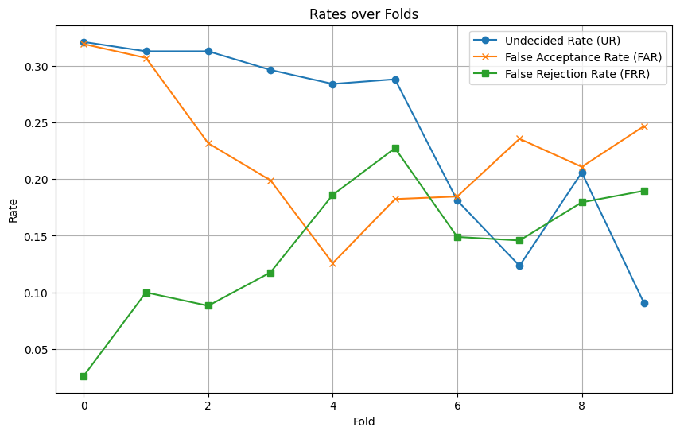

```python
import matplotlib.pyplot as plt

# plot the DataFrame columns
plt.figure(figsize=(10, 6))
plt.plot(m1_metrics.index, m1_metrics['ur'], label='Undecided Rate (UR)', marker='o')
plt.plot(m1_metrics.index, m1_metrics['far'], label='False Acceptance Rate (FAR)', marker='x')
plt.plot(m1_metrics.index, m1_metrics['frr'], label='False Rejection Rate (FRR)', marker='s')

# adding labels and title
plt.xlabel('Fold')
plt.ylabel('Rate')
plt.title('Rates over Folds')
plt.legend()
plt.grid(True)

# Display the plot
plt.show()
```

```python
m1_metrics
```

|  | ur | far | frr | learning_rate | threshold_A | threshold_notA |
| --- | --- | --- | --- | --- | --- | --- |
| 0 | 0.320988 | 0.319149 | 0.026316 | 0.010000 | 0.975000 | 1.025000 |
| 1 | 0.312757 | 0.306878 | 0.100000 | 0.009000 | 0.965250 | 1.014750 |
| 2 | 0.312757 | 0.231638 | 0.088235 | 0.008100 | 0.956563 | 1.005617 |
| 3 | 0.296296 | 0.198864 | 0.117647 | 0.007290 | 0.948815 | 0.997472 |
| 4 | 0.283951 | 0.125786 | 0.186047 | 0.006561 | 0.941898 | 0.990200 |
| 5 | 0.288066 | 0.182353 | 0.227273 | 0.005905 | 0.948078 | 0.996697 |
| 6 | 0.181070 | 0.184615 | 0.148936 | 0.005314 | 0.953676 | 0.990811 |
| 7 | 0.123457 | 0.235556 | 0.145833 | 0.004783 | 0.958744 | 0.985546 |
| 8 | 0.205761 | 0.210784 | 0.179487 | 0.004305 | 0.954158 | 0.980832 |
| 9 | 0.090535 | 0.246753 | 0.189655 | 0.003874 | 0.958266 | 0.976610 |

From the chart and data above, two candidate EERs at folds 6 and 8 can be identified, with a range of ~3%. However, fold six at `threshold_A` = 0.953676 and `threshold_notA` = 0.990811 has lower false labeling rates. Paired with a somewhat lower indecision rate, these were chosen as the model's inference parameters.

Now we will run the algorithm with our chosen thresholds on the holdout test set.

```python
# set decision thresholds to the best-performing values from our training loop above
holdout_threshold_A = m1_metrics.loc[6]['threshold_A']
holdout_threshold_notA = m1_metrics.loc[6]['threshold_notA']

# Sort x_holdout and y_holdout based on targets to create profiles [8, p. 260]
# Based on Spataner's answer on Reddit at https://www.reddit.com/r/learnpython/comments/rzw5w6/comment/hrxq8s8/ [24]
sorted_indices = np.argsort(m1_y_holdout)

m1_X_holdout_sorted = m1_X_holdout[sorted_indices]
m1_y_holdout_sorted = m1_y_holdout[sorted_indices]

# Now m1_X_holdout_sorted and m1_y_holdout_sorted are sorted based on the targets
# The first part of the array will contain all the negative samples (0's)
# The second part of the array will contain all the positive samples (1's)

# Find the split point between negative and positive samples
split_point = np.sum(m1_y_holdout_sorted == 0)

# Create profiles for negative and positive samples
m1_X_holdout_negative = m1_X_holdout_sorted[:split_point]
m1_X_holdout_positive = m1_X_holdout_sorted[split_point:]
# End of adapted code

m1_holdout_preds = np.array([])

# Run inference on the negative samples
for i, X in enumerate(m1_X_holdout_negative):
    # remove the current test example (q) from the author profile
    samples_minus_X = np.concatenate((m1_X_holdout_negative[:i],m1_X_holdout_negative[i+1:]))

    # Adapted from scikit-learn docs at https://scikit-learn.org/stable/modules/generated/sklearn.metrics.pairwise.manhattan_distances.html [23]
    delta_A = np.mean([manhattan_distances(np.reshape(X, (1, -1)), np.reshape(a, (1, -1)))[0][0] for a in m1_X_holdout_positive])
    delta_notA = np.mean([manhattan_distances(np.reshape(X, (1, -1)), np.reshape(not_a, (1, -1)))[0][0] for not_a in samples_minus_X])
    # End of adapted code

    # apply decision rule and extend predictions array with new predictions output
    m1_holdout_preds = np.append(m1_holdout_preds, apply_m1_decision_rule(delta_A, delta_notA, holdout_threshold_A, holdout_threshold_notA))

# Run inference on the positive samples
for i, X in enumerate(m1_X_holdout_positive):
    # remove the current test example (q) from the author profile
    samples_minus_X = np.concatenate((m1_X_holdout_positive[:i],m1_X_holdout_positive[i+1:]))

    # Adapted from scikit-learn docs at https://scikit-learn.org/stable/modules/generated/sklearn.metrics.pairwise.manhattan_distances.html [23]
    delta_A = np.mean([manhattan_distances(np.reshape(X, (1, -1)), np.reshape(a, (1, -1)))[0][0] for a in samples_minus_X])
    delta_notA = np.mean([manhattan_distances(np.reshape(X, (1, -1)), np.reshape(not_a, (1, -1)))[0][0] for not_a in m1_X_holdout_negative])
    # End of adapted code

    # apply decision rule and extend predictions array with new predictions output
    m1_holdout_preds = np.append(m1_holdout_preds, apply_m1_decision_rule(delta_A, delta_notA, holdout_threshold_A, holdout_threshold_notA))


# Output FEE metrics
ur, far, frr = get_far_and_fer_rates(m1_holdout_preds, m1_y_holdout_sorted)
print(f"ur: {ur}, far: {far}, frr: {frr}")
```

```
ur: 0.4457236842105263, far: 0.027491408934707903, frr: 0.19402985074626866
```

We get a UR of ~44%, a FAR of ~3%, and an FRR of ~19%.

These numbers are similar, though flipped, to those achieved by the Gaussian Naive Bayes classifier baseline, which had a FAR of ~16% and an FRR of ~3%.

Looking at the actual determinate predictions (those not labeled "don't know") reveals a fairly strong set of predictions.

```python
# cull out the np.nans in preds and the elements at matching indices in ground_truths
holdout_mask = np.isfinite(m1_holdout_preds)

holdout_preds_sans_nan = m1_holdout_preds[holdout_mask]
m1_y_holdout_sorted_sans_nan = m1_y_holdout_sorted[holdout_mask]
viewing_split_point = np.sum(m1_y_holdout_sorted_sans_nan == 0)
real_works_preds = holdout_preds_sans_nan[:viewing_split_point].astype(int)
imposter_works_preds = holdout_preds_sans_nan[viewing_split_point:]
print("Predictions on works by LaSalle (A). 1 means the model predicted that she wrote it.")
print(real_works_preds)
print("\nPredictions on works not by LaSalle (¬A). 0 means the model predicted that she did not write it.")
print(imposter_works_preds)
```

```
Predictions on works by LaSalle (A). 1 means the model predicted that she wrote it.
[0 0 0 0 0 0 0 0 0 0 0 0 0 0 0 0 0 0 0 0 0 0 0 0 0 0 0 0 0 0 0 0 0 0 0 0 0
 0 0 0 0 0 1 0 0 0 0 0 0 0 0 0 0 0 0 0 0 0 0 0 0 0 0 0 0 0 0 0 1 0 0 0 0 0
 0 0 0 0 0 0 0 0 0 0 0 0 0 0 0 0 0 0 0 0 0 0 0 0 0 0 0 0 0 0 0 0 0 0 0 0 0
 0 0 0 0 0 0 0 0 0 0 0 0 0 0 0 1 0 0 0 0 0 0 0 0 0 0 1 0 1 0 0 0 0 0 0 0 0
 0 0 0 0 0 0 0 0 0 0 0 0 0 0 1 0 0 0 0 0 0 0 0 0 0 0 0 0 0 0 0 0 0 0 0 0 0
 0 0 0 0 0 0 0 0 0 0 0 0 1 0 0 0 0 0 0 0 0 0 0 0 0 0 1 0 0 0 0 0 0 0 0 0 0
 0 0 0 0 0 0 0 0 0 0 0 0 0 0 0 0 0 0 0 0 0 0 0 0 0 0 0 0 0 0 0 0 0 0 0 0 0
 0 0 0 0 0 0 0 0 0 0 0 0 0 0 0 0 0 0 0 0 0 0 0 0]

Predictions on works not by LaSalle (¬A). 0 means the model predicted that she did not write it.
[1. 1. 0. 1. 1. 1. 1. 1. 1. 0. 0. 1. 1. 1. 0. 1. 1. 1. 1. 1. 1. 1. 1. 0.
 1. 1. 0. 1. 1. 1. 1. 1. 0. 0. 1. 0. 1. 1. 1. 0. 1. 1. 1. 1. 1. 1. 0. 0.
 1. 1. 0. 1. 1. 1.]
```

Unfortunately, the undecided rate of 44% is somewhat high.

It is important to note that the baseline (GNB) achieved similar performance without the ability to choose "don't know" as a label.

Let's look at the f1 score.

```python
# Import needed libraries
from sklearn.metrics import f1_score

m2_holdout_f1 = f1_score(m1_y_holdout_sorted_sans_nan, holdout_preds_sans_nan)
print(f"f1-score: {m2_holdout_f1}")
```

```
f1-score: 0.7961165048543689
```

While strong, it should be noted that this score is calculated from the labels (and matching ground truths) that were *not* predicted as "don't know".

##### DNN Implementation

The DNN algorithm:

Layer architecture and optimizer were chosen through experimentation. Categorical-cross-entropy was tested and found to perform worse. Several variations of deeper networks and larger (more connections) layers were tested, also resulting in lower evaluations on the test sets. The loss function was a natural choice given the binary nature of the problem and the need for confidence scores or continuous outputs representing likelihoods. ReLU activations were somewhat arbitrary but used given their ubiquity of use in such networks. The final sigmoid activation was necessary, given the binary classification problem. A dropout layer was added and tuned to guard against overfitting, given the small dataset.

```python
# Import needed libraries
from tensorflow.keras.models import Sequential
from tensorflow.keras.layers import Dense, Dropout
from tensorflow.keras.losses import binary_crossentropy
from tensorflow.keras.optimizers import Adam
from sklearn.model_selection import StratifiedKFold
import numpy as np
```

```python
# import warnings
# import tensorflow as tf
# import os

# warnings.filterwarnings('ignore')
# os.environ['TF_CPP_MIN_LOG_LEVEL'] = '0'  # or any {'0', '1', '2'}
# tf.get_logger().setLevel('ERROR')

# Declare constants
K = 10 # number of faux folds

# Define the K-fold Cross Validator
kfold = StratifiedKFold(n_splits=K, shuffle=True, random_state=SEED)

k = 0 # iterator to keep track of current fold

# Code adapted from Lucas Eduardo's GitHub article found at https://github.com/christianversloot/machine-learning-articles/blob/main/how-to-use-k-fold-cross-validation-with-keras.md [25]
# Model hyperparameters
no_classes = 1
loss_function = binary_crossentropy
optimizer = "Nadam"
batch_size = 50
no_epochs = 25
dropout_rates = np.linspace(0,0.5,K)
verbosity = 0
# End of adapted code

# create a pandas DataFrame to hold metrics and select best hyperparamters
m2_metrics = pd.DataFrame({'dropout rate': [], 'far': [], 'frr': [], 'f1-score': []})

for train, test in kfold.split(m2_X_train, m2_y_train):

    # Define the model architecture
    model = Sequential()
    model.add(Dense(64, activation='relu', input_shape=(m2_X_train.shape[1],)))
    model.add(Dense(128, activation='relu'))
    # Droput layer to reduce overfitting
    model.add(Dropout(rate=dropout_rates[k], seed=SEED))
    model.add(Dense(128, activation='relu'))
    model.add(Dense(64, activation='relu'))
    # Sigmoid activation for binary classification
    model.add(Dense(no_classes, activation='sigmoid'))

    # Code adapted from Lucas Eduardo's GitHub article found at https://github.com/christianversloot/machine-learning-articles/blob/main/how-to-use-k-fold-cross-validation-with-keras.md [25]
    # Compile the model
    model.compile(loss=loss_function,
                  optimizer=optimizer,
                  metrics=['Precision', 'Recall'])

    # Generate a print
    print(f'fold {k}')

    # Fit data to model
    history = model.fit(m2_X_train[train], m2_y_train[train],
              batch_size=batch_size,
              epochs=no_epochs,
              verbose=verbosity)

    # Generate generalization metrics
    scores = model.evaluate(m2_X_train[test], m2_y_train[test], verbose=verbosity)
    # End of adapted code

    truth = m2_y_train[test]
    preds = np.round(model.predict(m2_X_train[test], verbose=verbosity).flatten())
    _, far, frr = get_far_and_fer_rates(truth, preds)
    loss = scores[0]
    precision = scores[1]
    recall = scores[2]
    # Calculate the f1-score with the formula `f1 = 2 * (precision * recall)/(precision + recall)`
    f1 = 2 * (precision * recall)/(precision + recall) if precision + recall > 0 else 0

    print(f"far: {far}, frr: {frr}, f1-score: {f1}")

    m2_metrics.loc[len(m2_metrics)] = [dropout_rates[k], far, frr, f1]

    # Increase fold number
    k = k + 1
```

```
fold 0
far: 0.08928571428571429, frr: 0.16666666666666666, f1-score: 0.6956521930676551
fold 1
```

```
far: 0.07272727272727272, frr: 0.09090909090909091, f1-score: 0.7826086983563538
fold 2
```

```
far: 0.07407407407407407, frr: 0.15384615384615385, f1-score: 0.7500000084853833
fold 3
```

```
far: 0.10714285714285714, frr: 0.26666666666666666, f1-score: 0.5833333449231247
fold 4
```

```
far: 0.0392156862745098, frr: 0.14285714285714285, f1-score: 0.8333333134651184
fold 5
```

```
far: 0.09836065573770492, frr: 0.0, f1-score: 0.6666666666666666
fold 6
```

```
far: 0.02127659574468085, frr: 0.21052631578947367, f1-score: 0.8148148324754503
fold 7
```

```
far: 0.07272727272727272, frr: 0.1, f1-score: 0.7619047773127652
fold 8
```

```
far: 0.058823529411764705, frr: 0.2, f1-score: 0.75
fold 9
```

```
far: 0.07142857142857142, frr: 0.0, f1-score: 0.8000000143051146
```

```python
m2_metrics
```

|  | dropout rate | far | frr | f1-score |
| --- | --- | --- | --- | --- |
| 0 | 0.000000 | 0.089286 | 0.166667 | 0.695652 |
| 1 | 0.055556 | 0.072727 | 0.090909 | 0.782609 |
| 2 | 0.111111 | 0.074074 | 0.153846 | 0.750000 |
| 3 | 0.166667 | 0.107143 | 0.266667 | 0.583333 |
| 4 | 0.222222 | 0.039216 | 0.142857 | 0.833333 |
| 5 | 0.277778 | 0.098361 | 0.000000 | 0.666667 |
| 6 | 0.333333 | 0.021277 | 0.210526 | 0.814815 |
| 7 | 0.388889 | 0.072727 | 0.100000 | 0.761905 |
| 8 | 0.444444 | 0.058824 | 0.200000 | 0.750000 |
| 9 | 0.500000 | 0.071429 | 0.000000 | 0.800000 |

After running the K-fold algorithm many times (30-40), it was observed that a dropout rate of 0.222222 yielded the best metrics most of the time, with 0.111111 having the best metrics slightly less. One or the other was the top-performing dropout rate, roughly 90% of the time. These top-performing metrics were an f1-score ranging from 0.8 to 0.85 and EERs with ranges between 0.00 and ~0.15.

```python
# Define the model architecture
model = Sequential()
model.add(Dense(64, activation='relu', input_shape=(m2_X_train.shape[1],)))
model.add(Dense(128, activation='relu'))
# Droput layer to reduce overfitting
model.add(Dropout(rate=dropout_rates[4], seed=SEED))
model.add(Dense(128, activation='relu'))
model.add(Dense(64, activation='relu'))
# Sigmoid activation for binary classification
model.add(Dense(no_classes, activation='sigmoid'))

# Code adapted from Lucas Eduardo's GitHub article found at https://github.com/christianversloot/machine-learning-articles/blob/main/how-to-use-k-fold-cross-validation-with-keras.md [25]
# Compile the model
model.compile(loss=loss_function,
              optimizer=optimizer,
              metrics=['Precision', 'Recall'])

# Fit data to model
history = model.fit(m2_X_train, m2_y_train,
          batch_size=batch_size,
          epochs=no_epochs,
          verbose=verbosity)
# End of adapted code

# Predict the holdout set
m2_holdout_preds = np.round(model.predict(m2_X_holdout, verbose=verbosity).flatten())

_, m2_holdout_far, m2_holdout_frr = get_far_and_fer_rates(m2_y_holdout, m2_holdout_preds)
m2_holdout_loss = scores[0]
m2_holdout_precision = scores[1]
m2_holdout_recall = scores[2]
# Calculate the f1-score with the formula `f1 = 2 * (precision * recall)/(precision + recall)`
m2_holdout_f1 = 2 * (m2_holdout_precision * m2_holdout_recall)/(m2_holdout_precision + m2_holdout_recall)

print(f"far: {m2_holdout_far}, frr: {m2_holdout_frr}, f1-score: {m2_holdout_f1}")
```

```
far: 0.06679389312977099, frr: 0.20134228187919462, f1-score: 0.8000000143051146
```

These results are interesting and very near our previous model's performance of FAR = ~3%, FRR = ~20%, and F1 score = ~0.80. The only notable difference is a slightly higher FAR at ~7%. It is important to recognize that these results were obtained from a model without the ability to predict a label of "don't know." An EER range from 3% or 7 to 20% is substantial when compared to that obtained from Brocardo et al. at 8.21% to 16.73% <sup>[9, p. 2]</sup>.

This EER obtained by the DNN model is clearly under that obtained by the GNB baseline model of ~11% to ~27%.

#### The Love Letters

We will use our models to predict the likelihood of LaSalle Corbell Pickett's authorship of the love letters attributed to General George E. Pickett.

```python
# Run prediction on the love letters with model 1

# set decision thresholds to the best-performing values from our training loop above
holdout_threshold_A = m1_metrics.loc[6]['threshold_A']
holdout_threshold_notA = m1_metrics.loc[6]['threshold_notA']

m1_Q_preds = np.array([])

# Run inference on the Q chunks
for i, X in enumerate(f1_Q_norm):
    # Adapted from scikit-learn docs at https://scikit-learn.org/stable/modules/generated/sklearn.metrics.pairwise.manhattan_distances.html [23]
    delta_A = np.mean([manhattan_distances(np.reshape(X, (1, -1)), np.reshape(a, (1, -1)))[0][0] for a in f1_A_norm])
    delta_notA = np.mean([manhattan_distances(np.reshape(X, (1, -1)), np.reshape(not_a, (1, -1)))[0][0] for not_a in f1_notA_norm])
    # End of adapted code

    # apply decision rule and extend predictions array with new predictions output
    m1_Q_preds = np.append(m1_holdout_preds, apply_m1_decision_rule(delta_A, delta_notA, holdout_threshold_A, holdout_threshold_notA))
```

```python
# Output the percentage of chunks predicted "don't know"
m1_Q_preds_notnan_mask = np.isnan(m1_Q_preds)
print(f"Percent chunks labeled \"don't know\" by model 1: {len(m1_Q_preds[m1_Q_preds_notnan_mask])/len(m1_Q_preds) * 100:.0f}%")

# Output the percentage of chunks predicted to be written by LaSalle
m1_Q_preds_nan_mask = np.isfinite(m1_Q_preds)
m1_Q_decided_preds = m1_Q_preds[m1_Q_preds_nan_mask]
print(f"Percent chunks labeled as written by LaSalle (1) by model 1: {np.sum(m1_Q_decided_preds == 1)/len(m1_Q_preds) * 100:.0f}%")

# Output the percentage of chunks predicted not to be written by LaSalle
print(f"Percent chunks labeled as not written by LaSalle (0) by model 1: {np.sum(m1_Q_decided_preds == 0)/len(m1_Q_preds) * 100:.0f}%")
```

```
Percent chunks labeled "don't know" by model 1: 44%
Percent chunks labeled as written by LaSalle (1) by model 1: 8%
Percent chunks labeled as not written by LaSalle (0) by model 1: 47%
```

```python
# Run prediction on the love letters with model 2

# Predict the holdout set
m2_Q_preds = np.round(model.predict(np.array(F_Q_norm), verbose=verbosity).flatten())
```

```python
# Output the percentage of chunks predicted to be written by LaSalle
print(f"Percent chunks labeled as written by LaSalle (1) by model 2: {np.sum(m2_Q_preds == 1)/len(m2_Q_preds) * 100:.0f}%")

# Output the percentage of chunks predicted not to be written by LaSalle
print(f"Percent chunks labeled as not written by LaSalle (0) by model 2: {np.sum(m2_Q_preds == 0)/len(m2_Q_preds) * 100:.0f}%")
```

```
Percent chunks labeled as written by LaSalle (1) by model 2: 48%
Percent chunks labeled as not written by LaSalle (0) by model 2: 52%
```

### Conclusions

#### Performance Analysis & Comparative Discussion

The two models implemented in this study, the SPATIUM-L1 variant and the Deep Neural Network (DNN), showed comparable performance in the authorship verification task, but with some notable differences.

The SPATIUM-L1 variant achieved an Equal Error Rate (EER) range of ~3% to ~19%, with a False Acceptance Rate (FAR) of ~3% and a False Rejection Rate (FRR) of ~19%. The model also had a high undecided rate of 44%, indicating a conservative approach to classification. When making determinate predictions, SPATIUM-L1 achieved a strong F1 score of 0.796.

Both models outperformed the Gaussian Naive Bayes (GNB) baseline trained on the DNN feature set, which had an EER range of 11% to 27% and an F1 score of 0.608. They also outperformed the GNB trained on the SPATIUM-L1 inspired feature set which achieved an F1 score of 0.710. Its EER range was slightly more favorable though, outperforming both main models with a range from ~3% to ~16%.

To visualize the performance comparison:

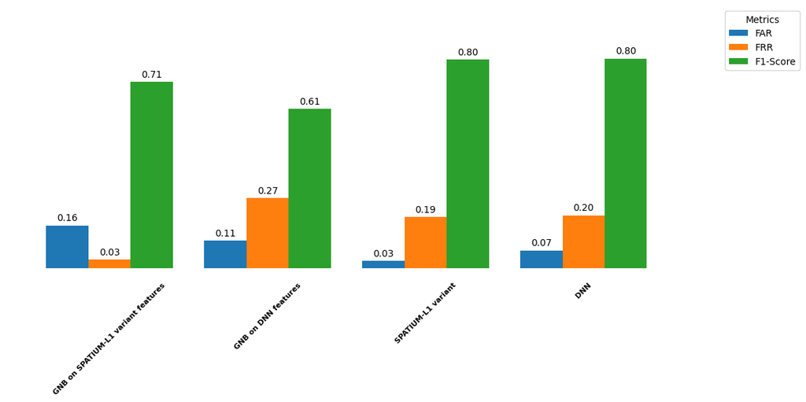

```python
generate_model_performance_plot() # See Appendix D
```

The statistical SPATIUM-L1 model offers interpretability, with its smaller and human interpretable feature set, and the ability to abstain from decisions when uncertain. This can be advantageous in high-stakes scenarios where false positives or negatives could have serious consequences <sup>[8, p. 262]</sup>. The model's performance on determinate predictions suggests it makes high-quality decisions when confident.

The DNN model demonstrates the power of deep learning in capturing complex stylometric patterns, such as character/word n-grams and vocabulary richness. Its slightly higher F1 score indicates better overall classification performance but at the cost of interpretability and the ability to say, "I don't know."

The choice between these models may depend on the specific application. When explainability is crucial, such as forensics and court cases, SPATIUM-L1 may be preferred. For applications prioritizing overall accuracy and where indecision is less desirable, the DNN model could be more suitable.

The performance difference between the models and the baseline underscores the potential effectiveness of both approaches for authorship verification tasks. However, the similar performance between SPATIUM-L1 and DNN suggests that for this particular dataset and problem, the added complexity of the feed-forward neural network may offer little gain over a statistical approach.

#### Project Summary and Reflections

The study presented here resulted from an enriching investigation into new territory for the author, with data cleaning being a massive part of this work (refer to Appendix B and C for more details). The feature selection and extraction processes, state-of-the-art research, and model experimentation were rewarding and enlightening. This study involved significant research into domain-specific and idiomatic nuances regarding American English in the late 19th and early 20th century, resulting in cross-disciplinary revelations that the author found inspiring.

Developing the SPATIUM-L1-inspired and DNN models was iterative. The DNN was easier to implement end-to-end due to Keras' high-level API but required more tuning. SPATIUM-L1, being niche with no high-level API, was more challenging to implement despite its theoretical simplicity. The author's alterations necessitated additional hyperparameter tuning compared to M. Kocher and J. Savoy's original work.

This research is applicable to authorial attribution, verification, and plagiarism detection. The SPATIUM-L1-inspired algorithm could be particularly useful in high-stakes scenarios like court cases due to its conservative, explainable approach. Its reliance on the top 200 most frequent terms makes it more human-interpretable. The author's extension of the original work through chunking and faux-K-fold cross-validation further enhances statistical robustness and prediction confidence.

Future work could incorporate named entity removal, as suggested in the original SPATIUM-L1 paper:

> "As another possible improvement, we can ignore specific topical terms or character names appearing frequently in an author profile, terms that can be selected in the feature set without being useful in discriminating between authors." <sup>[8, p. 266]</sup>

Extensive hyperparameter and architectural exploration using techniques like grid search could benefit the DNN model. Ensemble methods combining both models could potentially improve authorship verification accuracy.

Finally, on the issue of the authorship of the love letters, while perhaps the dramatist in the author felt a bit disappointed that the determination was not a strong one, at least both algorithms agreed. This consistency adds credibility to the findings. Bold assertions can be compelling, but if fundamentally unsound, they result in a disintegration of trust. Building models that give tempered output is arguably a paramount goal in machine learning model research at this time.

### References

[1] G. E. Pickett, L. S. C. Pickett, and Woodrow Wilson Collection, "The heart of a soldier: as revealed in the intimate letters of Genl. George E. Pickett," S. Moyle, New York, 1913. [Online]. Available: https://www.loc.gov/item/13008107/. [Accessed: Jun. 25, 2024].

[2] M. Koppel et al, "The "Fundamental Problem" of Authorship Attribution," English Studies, vol. 93, (3), pp. 284-291, 2012.

[3] G. W. Gallagher, "A Widow and Her Soldier: LaSalle Corbell Pickett as Author of the George E. Pickett Letters," *The Virginia Magazine of History and Biography*, vol. 94, no. 3, pp. 329-344, Jul. 1986. [Online]. Available: https://www.jstor.org/stable/4248894. [Accessed: May. 16, 2024].

[4] M. M. Campbell, "George Edward Pickett: A macro-historical/micro-historical perspective," Master's thesis, Texas Woman’s University, Denton, TX, USA, pp. 104-114, Aug. 1996.

[5] C. E. Janney, "One of the Best Loved, North and South: The Appropriation of National Reconciliation by LaSalle Corbell Pickett," *The Virginia Magazine of History & Biography*, vol. 116, no. 4, pp. 370-406, 2008.

[6] D. Paul, "The Confederacy was built on slavery. How can so many Southern whites still believe otherwise?," *The Washington Post*, Nov. 28, 2018. [Online]. Available: https://www.washingtonpost.com/news/magazine/wp/2018/11/28/feature/the-confederacy-was-built-on-slavery-how-can-so-many-southern-whites-still-believe-otherwise/. [Accessed: Jun. 18, 2024].

[7] L. J. Gordon, "LaSalle Corbell Pickett (1843–1931)," *Encyclopedia Virginia*, Dec. 7, 2020. [Online]. Available: https://encyclopediavirginia.org/entries/pickett-lasalle-corbell-1843-1931/. [Accessed: Jun. 18, 2024].

[8] M. Kocher and J. Savoy, "A simple and efficient algorithm for authorship verification," *Journal of the Association for Information Science and Technology*, vol. 68, (1), pp. 259-269, 2017.

[9] M. L. Brocardo, I. Traore, I. Woungang, and M. S. Obaidat, "Authorship verification using deep belief network systems," *International Journal of Communication Systems*, vol. 30, no. 12, 2017, pp. e3259. [Online]. Available: https://doi.org/10.1002/dac.3259. [Accessed: Jun. 19, 2024].

[10] J. L. Abramson, "Hoax, Fraud, Plagiarism, Forgery," *Oxford Research Encyclopedia of Literature*, 2023. [Online]. Available: https://doi.org/10.1093/acrefore/9780190201098.013.1070. [Accessed: Jun. 19, 2024].

[11] M. Koppel and J. Schler, "Authorship verification as a one-class classification problem," in 2004, . DOI: 10.1145/1015330.1015448.

[12] G. Robins, "Lost Cause Motherhood: Southern Women Writers," *Louisiana History: The Journal of the Louisiana Historical Association*, vol. 44, no. 3, pp. 275-300, Summer 2003. [Online]. Available: https://www.jstor.org/stable/4233937. [Accessed: Jun. 24, 2024].

[13] R. Waters, "Macaria and the Lost Cause Ideology," *Alabama Heritage Blog*, May 11, 2022. [Online]. Available: https://www.alabamaheritage.com/alabama-heritage-blog/macaria-and-the-lost-cause-ideology. [Accessed: Jun. 24, 2024].

[14] limasxgoesto0, "Answer to 'Python, remove all non-alphabet chars from string'" StackOverflow, Mar. 20, 2014. [Online]. Available: https://stackoverflow.com/a/22521156. [Accessed: Jun. 26, 2024].

[15] "FreqDist," *NLTK 3.6.7 documentation*, [Online]. Available: https://www.nltk.org/api/nltk.probability.FreqDist.html. [Accessed: Jun. 26, 2024].

[16] Tim Pietzcker, "Answer to 'Python: How can I calculate the average word length in a sentence using the .split command?'" StackOverflow, Oct. 6, 2012. [Online]. Available: https://stackoverflow.com/a/12761576. [Accessed: Jun. 26, 2024].

[17] "Academic," *Sequence Publishing*, [Online]. Available: https://sequencepublishing.com/1/academic/academic.html. [Accessed: Jun. 19, 2024].

[18] "ConditionalFreqDist," *NLTK 3.6.7 documentation*, [Online]. Available: https://www.nltk.org/api/nltk.probability.ConditionalFreqDist.html. [Accessed: Jun. 26, 2024].

[19] endolith, "Answer to 'Concatenate a NumPy array to another NumPy array'" StackOverflow, Mar. 19, 2012. [Online]. Available: https://stackoverflow.com/a/9775378. [Accessed: Jun. 28, 2024].

[20] Z. Relova, "3 Tips for Working with Imbalanced Datasets," *Towards Data Science*, Feb. 5, 2021. [Online]. Available: https://towardsdatascience.com/3-tips-for-working-with-imbalanced-datasets-a765a0f3a0d0. [Accessed: Jun. 28, 2024].

[21] German C M, "Answer to 'K-fold cross-validation with validation and test set'", *Data Science Stack Exchange*, Dec. 19, 2020. [Online]. Available: https://datascience.stackexchange.com/a/86913. [Accessed: Jun. 28, 2024].

[22] "sklearn.utils.shuffle," *scikit-learn 1.0.2 documentation*, [Online]. Available: https://scikit-learn.org/stable/modules/generated/sklearn.utils.shuffle.html#shuffle. [Accessed: Jun. 28, 2024].

[23] "sklearn.metrics.pairwise.manhattan_distances," *scikit-learn 1.0.2 documentation*, [Online]. Available: https://scikit-learn.org/stable/modules/generated/sklearn.metrics.pairwise.manhattan_distances.html. [Accessed: Jun. 29, 2024].

[24] u/[Spataner], "Sort pair numpy arrays based on the first one," *Reddit*, Jan. 9, 2022. [Online]. Available: https://www.reddit.com/r/learnpython/comments/rzw5w6/comment/hrxq8s8/. [Accessed: Jun. 29, 2024].

[25] L. Eduardo, "how-to-use-k-fold-cross-validation-with-keras.md," *GitHub*, Sep. 15, 2023. [Online]. Available: https://github.com/christianversloot/machine-learning-articles/blob/main/how-to-use-k-fold-cross-validation-with-keras.md. [Accessed: Jun. 30, 2024].

[26] "Naive Bayes," *scikit-learn 1.0.2 documentation*, [Online]. Available: https://scikit-learn.org/stable/modules/naive_bayes.html. [Accessed: Jul. 2, 2024].

[27] A. Nazareth, "Demystifying False Acceptance Rate (FAR) and False Rejection Rate (FRR) in electronic-KYC," *Dicorm Consulting*, Nov. 27, 2020. [Online]. Available: https://www.dicorm.com.my/post/demystifying-far-and-frr. [Accessed: Jul. 2, 2024].

### Appendix

#### Appendix A: Dataset Details

**A NOTE ON THE CONTENTS THIS OF DATASET:** Given that these works are written by Southern confederates during the time of the American Civil War, the contents are highly objectionable, consisting of xenophobic and anti-black rhetoric, pro-slavery arguments, and eye-dialect, among other problematic speech. **Please inspect this data with caution**.

##### LaSalle Corbell Pickett

| Title | Source | URL | Acquired Date |
| --- | --- | --- | --- |
| Pickett and His Men (1899) | Library of Congress | https://tile.loc.gov/storage-services/public/gdcmassbookdig/picketthismen01pick/picketthismen01pick_djvu.xml | 2024-05-19 |
| Kunnoo Sperits and Others (1900) | Internet Archive | https://archive.org/download/kunnoosperitsoth00pickiala/kunnoosperitsoth00pickiala_djvu.xml | 2024-05-20 |
| Yule Log (1900) | HathiTrust.org | https://babel.hathitrust.org/cgi/pt?id=hvd.hn6gb3 | 2024-06-17 |
| Ebil Eye (1901) | HathiTrust.org | https://babel.hathitrust.org/cgi/pt?id=osu.32435058048737 | 2024-05-22 |
| Jinny (1901) | HathiTrust.org | https://babel.hathitrust.org/cgi/pt?id=osu.32435079799953 | 2024-05-22 |
| Digging Through to Manila (1905) | Library of Congress | https://tile.loc.gov/storage-services/public/gdcmassbookdig/diggingthroughto00pick/diggingthroughto00pick_djvu.xml | 2024-05-22 |
| Literary Hearthstones of Dixie (1912) | Project Gutenberg | https://www.gutenberg.org/ebooks/16622 | 2024-05-22 |
| The Bugles of Gettysburg (1913) | Internet Archive | https://ia801304.us.archive.org/33/items/buglesofgettysbu0000lasa/buglesofgettysbu0000lasa_djvu.xml | 2024-05-22 |
| Across My Path: Memories of People I Have Known (1916) | Library of Congress | https://tile.loc.gov/storage-services/public/gdcmassbookdig/acrossmypath00pick/acrossmypath00pick_djvu.xml | 2024-05-22 |
| What Happened to Me … (1917) | Project Gutenberg | https://www.gutenberg.org/ebooks/50001 | 2024-06-24 |
| The Fourth Massachusetts Cavalry in the Closing Scenes of the War for the Maintenance of the Union, from Richmond to Appomattox (1910) | Project Gutenberg | https://www.gutenberg.org/ebooks/31977 | 2024-05-22 |

##### Love Letters

| Title | Source | URL | Acquired Date |
| --- | --- | --- | --- |
| The Heart of a Soldier, As Revealed in the Intimate Letters of Gen'l George E. Pickett, C.S.A. (1913) | Library of Congress | https://tile.loc.gov/storage-services/public/gdcmassbookdig/heartofsoldieras00pick/heartofsoldieras00pick_djvu.xml | 2024-05-22 |
| Soldier of the South: General Pickett's War Letters to His Wife (edited by Arthur Crew Inman, 1928) | HathiTrust.org | https://babel.hathitrust.org/cgi/pt?id=uc1.$b61025 | 2024-05-22 |

##### Imposters

| Title | Source | URL | Acquired Date |
| --- | --- | --- | --- |
| A Diary from Dixie by Mary Boykin Chesnut (1905) | Project Gutenberg | https://www.gutenberg.org/ebooks/60908 | 2024-06-23 |
| Vashti; Or, Until Death Us Do Part by Augusta J. Evans (1869) | Project Gutenberg | https://www.gutenberg.org/ebooks/31620 | 2024-06-23 |
| A Speckled Bird by Augusta J. Evans (1902) | Project Gutenberg | https://www.gutenberg.org/ebooks/36029 | 2024-06-23 |
| Macaria by Augusta J. Evans (1863) | Project Gutenberg | https://www.gutenberg.org/ebooks/27811 | 2024-06-23 |
| St. Elmo by Augusta J. Evans (1866) | Project Gutenberg | https://www.gutenberg.org/ebooks/4553 | 2024-06-23 |
| Balcony Stories by Grace Elizabeth King (1893) | Project Gutenberg | https://www.gutenberg.org/ebooks/11514 | 2024-06-23 |
| Recollections and Letters of General Robert E. Lee by Robert E. Lee (1904) | Project Gutenberg | https://www.gutenberg.org/ebooks/2323 | 2024-06-23 |
| From Manassas to Appomattox: Memoirs of the Civil War in America by James Longstreet (1896) | Project Gutenberg | https://www.gutenberg.org/ebooks/38418 | 2024-06-23 |
| Lee and Longstreet at High Tide: Gettysburg in the Light of the Official Records by Helen D. Longstreet (1904) | Project Gutenberg | https://www.gutenberg.org/ebooks/44459 | 2024-06-23 |
| The Heritage of The South by Jubal Anderson Early (1867) | Project Gutenberg | https://www.gutenberg.org/ebooks/63254 | 2024-06-23 |

#### Appendix B: Dataset Cleaning Procedures

##### Data collection

Python, requests, web browsing, and Selenium were used to collect data from the web.

The Wikipedia page for La Salle Corbell Pickett was used to find the titles of her works: https://en.wikipedia.org/wiki/LaSalle_Corbell_Pickett#Works

Two contain the love letters of General George E. Pickett to his wife,

- The Heart of a Soldier, As Revealed in the Intimate Letters of Gen'l George E. Pickett, C.S.A. (1913)
- Soldier of the South: General Pickett's War Letters to His Wife (1928)

Since all works were published before 1923, they are in the public domain: https://guides.library.oregonstate.edu/copyright/publicdomain#

##### Data cleaning

###### HathiTrust

All works obtained from HathiTrust.org were in plain text, single file per page, format. The first step was to combine all pages into a single file for each work. Before doing so, irrelevant pages were removed. For example, the title page, table of contents, forwards by non-authors, and blank pages were removed.

Next, upon inspection, it was found that every page contained some preambles from HathiTrust followed by a starting marker in the form of two # symbols, a book page number (e.g., `## p. 170`), that sometimes would not be present, and always an absolute page number (e.g., `(#192)`), as shown below:

```
txt
## p. 170 (#192) ############################################
```

Following this marker was always an empty line, followed by the text of the page.

This fact was used to construct the following python script which was used to remove the preambles and markers from the text files:

`hathitrust_preamble_remover.py` (see Appendix C)

The second step was to remove page numbers and titles from the text files. In most cases this information was present and took up the first two lines of the files. In a few cases this information was not present, or only took up one line. The pages were analyzed and a small list of pages which did not meet the *first two lines* criteria was curated. The following python script was used to remove the page numbers and titles for pages not in this list:

`remove_first_two_lines.py` (see Appendix C)

The untouched pages were then cleaned by hand.

Next, the text was concatenated into a single file for each work. The following Zsh script was used to concatenate the text files:

`concat.zsh` (see Appendix C)

Finally, the text was scanned by eye to identify page number lines missed by the previous scripts. These were easy to identify as they were the only lines in the file that had one to three characters only. They were removed by hand.

Roughly the same process was followed for all works obtained from HathiTrust.

While manually cleaning the text files, it was found that the OCR had made several mistakes. For example, words were often split at the end of lines, but it appears that the OCR consistently added either a space or some superfluous punctuation at the end of the line. A routine that could join 'words' at the end and beginning of lines, check if the joined word is in the English dictionary, and if not, keep the words separate, was written. The following Python script was used to clean the text files:

`ocr_eol_mistake_cleaner.py` (see Appendix C)

It was also observed that the OCR had made consistent mistakes across all works. Examples of these mistakes include: `I` being read as `1`, `c` being read as `e` (especially in certain contexts, such as the word 'officer' which was often mis-scanned as 'offieer'), and `w` being read as `vv`. It was determined that if one such mistakes was identified it was likely that the same mistake was made many times throughout the entire corpus. This presented an opportunity to generalize a correction process whereby the mistakes could be identified and corrected in a single pass. The following Python script using the SpaCy and spellchecker libraries was used to correct the OCR mistakes:

`spacy_autocorrect.py` (see Appendix C)

This routine prompts the user to correct the mistakes it finds. The user can choose to correct the mistake from a given list of suggestions, provide a custom correction, skip the mistake, or skip the mistake and all subsequent mistakes of the same type. It builds a dictionary of corrections and skip decisions that is saved to a file and propagated through the document and in subsequent runs. This naive approach undoubtedly introduced some new errors, but these are far outnumbered by the corrections made.

Finally, the text was minified by combining all lines into a single line using the NVIM command:

```
:%s/\n/ /g
```

###### Internet Archive and Library of Congress

All works obtained from the Internet Archive and Library of Congress were in XMLDjVu format. The following Python script was used to convert the XMLDjVu to `.txt` files:

`xmldjvu_to_txt.py` (see Appendix C)

The resulting text files were then inspected and found to be very similar to the HathiTrust text files. The same cleaning process was followed.

###### The Project Gutenberg

The work obtained from The Project Gutenberg was in HTML format. The fidelity of the textual content was very high, and the text was extracted by hand by identifying certain tags to be removed, such as tags with classes of `poem`, `footnote`, `boilerplate`, `chapter`, and `quote`. Extraneous layout and non-textual tags were also removed, such as `img`, `hr`, `br`. The resulting rendered HTML was then copied and pasted into a text file.

##### Imposter Texts

All imposter texts were obtained from The Project Gutenberg and in HTML format. The collection and cleaning process was the same as for the other Project Gutenberg text described above.

#### Appendix C: Data Cleaning Routines

`hathitrust_preamble_remover.py`

[output not shown]

`remove_first_two_lines.py`

```
import os


def remove_first_two_lines(input_folder, output_folder, exclusion_list):
    if not os.path.exists(output_folder):
        os.makedirs(output_folder)

    # Convert exclusion list to a set for faster lookups
    exclusion_set = set(exclusion_list)

    # Iterate through each file in the input folder
    for filename in os.listdir(input_folder):
        # Check if the file has a .txt extension
        if filename.endswith(".txt"):
            # Extract the integer part of the filename
            file_number = int(filename.split(".")[0])

            # Construct the full path to the file
            file_path = os.path.join(input_folder, filename)

            # Read the file and remove the first two lines
            with open(file_path, "r") as file:
                lines = file.readlines()

            # Construct the output path
            output_path = os.path.join(output_folder, filename)

            # If the file number is in the exclusion set, write it to the output
            # file
            if file_number in exclusion_set:
                with open(output_path, "w") as file:
                    file.writelines(lines)
                continue

            # Write the file content without the first two lines
            with open(output_path, "w") as file:
                file.writelines(lines[2:])

    print(f"Cleaned text files have been saved to {output_folder}")


input_folder = "lasalle_corbell_pickett/ebil_eye_1_preamble_removed"
output_folder = (
    "lasalle_corbell_pickett/ebil_eye_2_first_two_lines_removed"
)
exclusion_list = [32, 33, 60, 83, 94,95, 106, 108, 109, 152, 153, 184]
remove_first_two_lines(input_folder, output_folder, exclusion_list)
```

`concat.zsh`

```
#!/bin/zsh

# Define the output path (one level up)
output_path="../ebil_eye.txt"

# Define an array with all .txt files in the directory
files=(*.txt)

# Sort the files numerically using sort command
sorted_files=($(printf '%s\n' "${files[@]}" | sort -n))

# Concatenate the sorted files
cat "${sorted_files[@]}" > "$output_path"
```

`ocr_eol_mistake_cleaner.py`

```
import re

import enchant


def clean_ocr_mistakes(input_file, output_file):
    # Flag to output if any merges were made
    merges_made = False

    # Initialize the dictionary
    dictionary = enchant.Dict("en_US")

    # Define the pattern to match words at the end of lines
    word_end_pattern = re.compile(r"(\w+)([\s\W]*)$")

    # Read the file and clean the OCR mistakes
    with open(input_file, "r") as file:
        lines = file.readlines()

    # Clean the OCR mistakes
    cleaned_lines = []
    i = 0

    while i < len(lines) - 1:
        line = lines[i]
        next_line = lines[i + 1]

        # Match the word at the end of the line
        match = word_end_pattern.search(line)
        if match:
            # Extract the word and potential punctuation at the end of the line
            word = match.group(1)
            rest = match.group(2)

            # Get the first word of the next line
            next_word_match = re.match(r"(\w+)", next_line)
            if next_word_match:
                next_word = next_word_match.group(1)
                # Check if the combined word is valid
                if dictionary.check(word + next_word):
                    # Join the word with the first word of the next line
                    combined_word = word + next_word
                    rest_of_next_line = next_line[len(next_word) :]

                    # Construct the combined line without duplicating the next line's content
                    combined_line = (
                        line.rstrip(word + rest) + combined_word + rest_of_next_line
                    )

                    # Add the combined line to cleaned_lines
                    cleaned_lines.append(combined_line)

                    # Set the flag to True
                    merges_made = True

                    # Skip to the next line after the merged line
                    i += 1
                else:
                    # If not valid, add the original line
                    cleaned_lines.append(line)
            else:
                # If no word match in next line, add the original line
                cleaned_lines.append(line)
        else:
            # If no match at end of line, add the original line
            cleaned_lines.append(line)

        # Move to the next line
        i += 1

    # Append the last line if it wasn't part of a merge
    if i == len(lines) - 1:
        cleaned_lines.append(lines[-1])

    # Write the cleaned content to a new file
    with open(output_file, "w") as file:
        file.writelines(cleaned_lines)

    print(
        "OCR mistakes have been cleaned." if merges_made else "No OCR mistakes found."
    )
    print(f"Cleaned text file has been saved to {output_file}")


input_file = "lasalle_corbell_pickett/ebil_eye_3_manual_cleanup.txt"
output_file = "lasalle_corbell_pickett/ebil_eye_4_ocr_eol_mistakes_cleaned.txt"
clean_ocr_mistakes(input_file, output_file)
```

`spacy_autocorrect.py`

```
import json
import os

import spacy
from spellchecker import SpellChecker

# Load English tokenizer, tagger, parser, NER, and word vectors
nlp = spacy.load("en_core_web_sm")

# Initialize the spell checker
spell = SpellChecker()


def underline(text):
    """Applies an underline effect using ANSI escape sequences."""
    return f"\033[4m{text}\033[0m"


def print_suggestions(candidates, offset, context_string):
    """Prints the candidate corrections formatted to align with the offset in the context."""
    print(
        "------------------------------------------------------------------------------------------------------------"
    )
    print(context_string)
    if candidates:
        for index, suggestion in enumerate(candidates, start=1):
            # Print each suggestion correctly spaced according to its position.
            print(f"{index}. {suggestion}".rjust(len(suggestion) + offset))


def load_correction_dict(filename="correction_dict.json"):
    """Load the correction dictionary from a file, or initialize it as empty if the file doesn't exist."""
    if os.path.exists(filename):
        with open(filename, "r") as file:
            return json.load(file)
    else:
        return {}  # Return an empty dictionary if the file does not exist


correction_dict = (
    load_correction_dict()
)  # Dictionary to store user's previous corrections and skip decisions


def save_correction_dict(correction_dict, filename="correction_dict.json"):
    """Save the correction dictionary to a file."""
    with open(filename, "w") as file:
        json.dump(correction_dict, file)


def check_word(token, total_tokens):
    """Check if a word is misspelled and suggest corrections if needed."""
    word = token.text
    if word in correction_dict:
        return correction_dict[word], False

    if not token.is_alpha:  # Skip punctuation and non-alpha tokens
        return word, False

    candidates = list(spell.candidates(word) or [])
    if candidates and candidates[0].lower() != word.lower():
        # Display up to 5 words before and after the current word
        start = max(0, token.i - 5)
        end = min(token.i + 6, total_tokens)
        context_tokens = token.doc[start:end]

        # Building the context string with underlined current word
        context_parts = []
        underline_start = 0  # To calculate the start position of the underlined word
        for i, t in enumerate(context_tokens):
            if t == token:
                context_parts.append(underline(t.text_with_ws))
                underline_start = sum(len(t_.text_with_ws) for t_ in context_tokens[:i])
            else:
                context_parts.append(t.text_with_ws)
        context_string = "".join(context_parts).replace("\n", " ")

        print_suggestions(candidates, underline_start, context_string)
        print(
            f"-------------------------------------------------- {token.i/total_tokens:.0%}"
        )

        while True:
            action = input(
                "Accept with number, custom (c), skip and propagate (s), skip without propagate (k), or stop (x): "
            )
            print("\n")
            if action.isdigit() and 1 <= int(action) <= len(candidates):
                chosen_correction = candidates[int(action) - 1]
                correction_dict[word] = chosen_correction
                return chosen_correction, False
            elif action == "c":
                custom_word = input("Enter your custom correction: ")
                correction_dict[word] = custom_word
                return custom_word, False
            elif action == "s":
                correction_dict[word] = word
                return word, False
            elif action == "k":
                return word, False
            elif action == "x":
                return None, True
            else:
                print(
                    "Invalid input. Please enter a valid number, 'c' for custom, 's' to skip and propagate, 'k' to skip without propagate, or 'x' to stop."
                )
    return word, False


def correct_text(text):
    """Correct the text by checking each word."""
    doc = nlp(text)
    total_tokens = len(doc)
    corrected_text = []
    for token in doc:
        result, stop_correction = check_word(token, total_tokens)
        if result is not None:
            # Append the corrected word with the original trailing whitespace
            corrected_text.append(result + token.whitespace_)
        else:
            # Append the original text with whitespace
            corrected_text.append(token.text_with_ws)
        if stop_correction:
            # Concatenate the remaining part of the text directly using text_with_ws
            remaining_text = "".join(t.text_with_ws for t in doc[token.i + 1 :])
            return "".join(corrected_text) + remaining_text, True
    return "".join(corrected_text), False


def process_file(input_path, output_path):
    """Process the input file and write the corrected text to the output file."""
    os.makedirs(os.path.dirname(output_path), exist_ok=True)
    try:
        with open(input_path, "r", encoding="utf-8") as file:
            full_text = file.read()

        corrected_text, stop_correction = correct_text(full_text)
        with open(output_path, "w", encoding="utf-8") as file:
            save_correction_dict(correction_dict)
            file.write(corrected_text)

        if stop_correction:
            print("Correction process stopped by user.")
    except Exception as e:
        print(f"An error occurred: {e}")
        raise

    print(f"Corrected text written to {output_path}")


input_path = "midterm/data/test_data/in/what_happened_to_me.txt"
output_path = "midterm/data/test_data/out/what_happened_to_me.txt"
process_file(input_path, output_path)
```

`xmldjvu_to_txt.py`

```
import os
import xml.etree.ElementTree as ET


def get_text_from_djvuxml(input_folder, output_folder):
    # Parse the XML file
    tree = ET.parse(input_folder)
    root = tree.getroot()

    # Create a directory to save the text files
    os.makedirs(output_folder, exist_ok=True)

    # Extract text content and save each page to a separate .txt file
    for page in root.findall(".//OBJECT"):
        page_id = (
            page.find('.//PARAM[@name="PAGE"]')
            .get("value")
            .split("_")[-1]
            .split(".")[0]
        )
        page_text = []

        for region in page.findall(".//REGION"):
            for line in region.findall(".//LINE"):
                # Join all words within a line to form the full text of the line
                words = [word.text for word in line.findall(".//WORD")]
                line_text = " ".join(words)
                page_text.append(line_text)

        # Join all lines to form the full text of the page
        full_text = "\n".join(page_text)

        # Save the text to a file
        with open(f"{output_folder}/page_{page_id}.txt", "w", encoding="utf-8") as file:
            file.write(full_text)

    print("Text extraction completed.")


input_folder = "midterm/data/original/george_pickett/heartofsoldieras00pick_djvu.xml"
output_folder = "midterm/data/in_process/george_pickett/heart_of_soldier"

get_text_from_djvuxml(input_folder, output_folder)
```

#### Appendix D: Model Performance Plot

```python
def generate_model_performance_plot():
    # Create a bar chart here comparing the FAR, FRR, and F1 scores of SPATIUM-L1, DNN, and GNB baseline
    import pandas as pd
    import matplotlib.pyplot as plt

    model_performances = pd.DataFrame({
        "GNB on SPATIUM-L1 variant features": [0.16262975778546712, 0.03125, 0.7100591715976331],
        "GNB on DNN features": [0.10536044362292052, 0.26627218934911245, 0.6076923076923076],
        "SPATIUM-L1 variant": [0.027491408934707903, 0.19402985074626866, 0.7961165048543689],
        "DNN": [0.06679389312977099, 0.20134228187919462, 0.8000000143051146],
    }, index=["FAR","FRR","F1-Score"])

    # Transpose to group by model
    model_performances_transposed = model_performances.T

    # Create bar plot
    ax = model_performances_transposed.plot(kind='bar', figsize=(12, 6), width=0.8)

    # Remove border for aesthetics
    ax.axis('off')

    # Add value labels
    for container in ax.containers:
        ax.bar_label(container, fmt='%.2f', padding=3)

    # Adjust legend
    plt.legend(title='Metrics', bbox_to_anchor=(1.05, 1), loc='upper left')

    # Add model labels
    for i, model in enumerate(model_performances_transposed.index):
        ax.text(i, -0.05, model, ha='center', va='top', rotation=45, fontweight='bold', fontsize=8)

    # Set y-axis limit to make room for labels at the bottom
    ax.set_ylim(-0.2, 1)

    # Adjust layout to prevent cutting off labels
    plt.tight_layout()

    # Adjust the subplot to leave some space at the bottom for labels
    plt.subplots_adjust(bottom=0.2)

    plt.show()
```